# metabolomics analysis for mSphere, Carey et al. 2018

Maureen A Carey

updated March, 2018

1 Set working directory and run helper function (to load libraries and functions) (warnings off here for package loading)

2 Open datafile

```r
raw_file = read.csv("/Users/maureencarey/local_documents/work/metabolomics_methods/data/met_methods_raw_data.txt",
                    sep = "\t", header = T, colClasses = c(rep(NA, 14), rep('numeric',35)),
                    na.strings=c('',"NA"), stringsAsFactors = F)

fig1D = raw_file[1:375,-c(1,5:29)] # select specified samples and remove empty last row
raw_file_comp1 = raw_file[1:375,-c(1,3:29)] # select specified samples, and remove extra metabolite identifiers and last empty row

print(raw_file_comp1[raw_file_comp1$BIOCHEMICAL == 'kynurenine',])
```

```
##     BIOCHEMICAL BAT_A_minus BAT_B_minus BAT_C_minus BAT_D_minus
## 216  kynurenine          NA          NA          NA          NA
##     BAT_E_minus BAT_A_plus BAT_B_plus BAT_C_plus BAT_D_plus BAT_E_plus
## 216          NA         NA         NA      68319      90413      83993
##     PUR_A_minus PUR_B_minus PUR_C_minus PUR_D_minus PUR_E_minus PUR_A_plus
## 216          NA       99274       76853          NA          NA         NA
##     PUR_B_plus PUR_C_plus PUR_D_plus PUR_E_plus
## 216         NA         NA         NA         NA
```

```r
print(raw_file_comp1[raw_file_comp1$BIOCHEMICAL == 'HEPES',])
```

```
##     BIOCHEMICAL BAT_A_minus BAT_B_minus BAT_C_minus BAT_D_minus
## 204       HEPES    52421688    34646640    52154024     3107028
##     BAT_E_minus BAT_A_plus BAT_B_plus BAT_C_plus BAT_D_plus BAT_E_plus
## 204    20674352   12947215   10051431   12764437    8897631   19885278
##     PUR_A_minus PUR_B_minus PUR_C_minus PUR_D_minus PUR_E_minus PUR_A_plus
## 204    11310459    14023294    22549960    13391750    25076902    3680629
##     PUR_B_plus PUR_C_plus PUR_D_plus PUR_E_plus
## 204    8731711   11887953    8462946   27530648
```

```r
print(raw_file_comp1[raw_file_comp1$BIOCHEMICAL == 'phenol red',])
```

```
##     BIOCHEMICAL BAT_A_minus BAT_B_minus BAT_C_minus BAT_D_minus
## 289  phenol red      372665      476177      372379       21492
##     BAT_E_minus BAT_A_plus BAT_B_plus BAT_C_plus BAT_D_plus BAT_E_plus
## 289      224990      77641      55806     106406      47024      79031
##     PUR_A_minus PUR_B_minus PUR_C_minus PUR_D_minus PUR_E_minus PUR_A_plus
## 289      389329      484091      119140      133312      294313         NA
##     PUR_B_plus PUR_C_plus PUR_D_plus PUR_E_plus
## 289      41535      62041      37819     119878
```

3 Count mets detected and generate Fig 1D

```r
raw = raw_file_comp1
print('number of metabolites in all samples')
```

```
## [1] "number of metabolites in all samples"
```

```r
dim(na.omit(raw)) #in all
```

```
## [1] 155  21
```

```r
print('number of metabolites in each sample')
```

```
## [1] "number of metabolites in each sample"
```

```r
# for (i in 2:ncol(raw)) { print(length(na.omit(raw[,i]))) }
rm(raw)

m = melt(fig1D, id.vars = c("BIOCHEMICAL", "SUPER_PATHWAY", "SUB_PATHWAY"))
m2 = mutate(m, val2 = ifelse(!is.na(value),1,0)) # Is metabolite measured in sample, yes/no

change_pathways = as.data.frame(rbind(c('Xenobiotics','Other'),
                                      c('Amino Acid','AA/Peptides'),
                                      c('Peptide','AA/Peptides'),
                                      c('Cofactors and Vitamins','Cofactors')))
for (i in 1:nrow(change_pathways)) {
  search_term = as.character(change_pathways$V1[i])
  replace_term = as.character(change_pathways$V2[i])
  m2$SUPER_PATHWAY = ifelse(m2$SUPER_PATHWAY == search_term,replace_term,m2$SUPER_PATHWAY)}

m4 = m2 %>%
  mutate(variable2 = paste(substr(as.character(variable), 1, 4), substr(variable, 7, nchar(as.character(variable))), sep='')) %>%
  group_by(BIOCHEMICAL, SUPER_PATHWAY, variable2) %>%
  summarise(samples = sum(val2)) %>% arrange(samples) %>%
  mutate(detected = ifelse(samples == 0, NA, 'detected')) %>% na.omit() %>%
  mutate(drug = ifelse(substr(variable2, 4,6)== '_mi','untreated','with DHA'),
         clone = substr(variable2, 1,3),
         sens_res = ifelse(clone == 'BAT','Resistant (MRA-1240)','Sensitive (MRA-1238)'))

m5 = m2 %>%
  mutate(variable2 = paste(substr(as.character(variable), 1, 4), substr(variable, 7, nchar(as.character(variable))), sep='')) %>%
  group_by(BIOCHEMICAL, SUPER_PATHWAY) %>%
  summarise(samples = sum(val2)) %>% arrange(samples) %>%
  mutate(detected = ifelse(samples == 0, NA, 'detected')) %>% na.omit() %>%
  mutate(group = 'all samples')

p1 = ggplot(data = m5, aes(x = SUPER_PATHWAY, y = samples, fill = SUPER_PATHWAY)) +
  geom_boxplot() +
  theme(axis.title = element_blank(),
        axis.ticks = element_blank(),
        strip.text.x = element_text(size = 7, family = "Helvetica"),
        panel.grid.major = element_blank(),
        axis.text.y = element_text(size = 7, family = "Helvetica"),
        #strip.background = element_blank(),
        legend.text = element_text(size = 6, family = "Helvetica"),
        plot.margin = ggplot2::margin(1,1,1,1,"mm"),
        axis.text.x = element_blank()) +
  guides(fill = FALSE) + facet_wrap(~group)

p2 = ggplot(data = m4, aes(x = SUPER_PATHWAY, y = samples, color = SUPER_PATHWAY)) +
  geom_jitter(size = .25) + facet_grid(sens_res~drug) +
  theme(axis.title = element_blank(),
        axis.ticks = element_blank(),
        panel.grid.major = element_blank(),
        axis.text.y = element_text(size = 7, family = "Helvetica"),
        axis.text.x = element_text(size = 7, angle = -45, vjust = 1, hjust = 0, family = "Helvetica"),
        legend.title = element_blank(),
        plot.margin = ggplot2::margin(1,1,1,1,"mm"),
        strip.text = element_text(size = 7, margin = ggplot2::margin(0.1,0.1,0.1,0.1,"mm"), family = "Helvetica"),
        #strip.background = element_blank(),
        legend.text = element_text(size = 6, family = "Helvetica"),
        legend.position="bottom") + guides(color = F)

# grid.newpage()
# lay <- rbind(c(1,1,1,2,2,2,2,2,2),
#              c(1,1,1,2,2,2,2,2,2))
# plot_final = grid.arrange(p1,p2,ncol = 2, nrow = 1, layout_matrix = lay)#, widths = 2:2)
# ggsave('dec122017_fig1D.pdf',plot_final, height = 3, width = 3.5, units = "in")
ggsave('feb2018_fig1C.pdf',p2, height = 2.8, width = 3.5, units = "in")
# devSVG(file = "dec122017_fig1D.svg", width = 3.5, height = 3,xmlHeader = T)
# plot(plot_final)
# dev.off()
```

```r
rm(m, m2,m4, m5)

raw1 = prep_raw(raw_file_comp1)
identifiers = prep_sample_identifiers(raw1)
melted = melt(raw1); melted_na = na.omit(melted); tab = table(melted_na$variable)
print(tab)
```

```
##
## BAT_A_minus BAT_B_minus BAT_C_minus BAT_D_minus BAT_E_minus  BAT_A_plus
##         225         260         267         195         258         230
##  BAT_B_plus  BAT_C_plus  BAT_D_plus  BAT_E_plus PUR_A_minus PUR_B_minus
##         216         225         211         239         232         240
## PUR_C_minus PUR_D_minus PUR_E_minus  PUR_A_plus  PUR_B_plus  PUR_C_plus
##         223         233         242         182         207         242
##  PUR_D_plus  PUR_E_plus
##         212         223
```

```r
measured_mets = as.data.frame(matrix(NA,nrow = 20, ncol = 1)); i = 1
for (x in tab) {
  measured_mets[i,1] = x
  rownames(measured_mets)[i] = rownames(tab)[i]
  i = i+1 }

df_for_cor = identifiers[c(3,5,6,9),]; colnames(df_for_cor) = identifiers[3,]
df1 = as.data.frame(t(df_for_cor)); df2 = as.data.frame(tab); rownames(df2) = df2$Var1
df_for_cor = merge(df1, df2, by = "row.names")
df_for_cor$CLIENT_IDENTIFIER = NULL; df_for_cor$Var1 = NULL
rownames(df_for_cor) = df_for_cor$Row.names; df_for_cor = df_for_cor[,-c(1)]

indx = sapply(df_for_cor, is.factor)
df_for_cor[indx] = lapply(df_for_cor[indx], function(x) as.character(x))
indx = sapply(df_for_cor, is.character)
df_for_cor[indx] = lapply(df_for_cor[indx], function(x) as.numeric(x))

cor_df = cor(df_for_cor)
print(cor_df)
```

```
##                 CLIENT_PROTEIN DSDNA_ASSAY TOTAL_PARASITES       Freq
## CLIENT_PROTEIN      1.00000000 -0.01098599       0.1091824 -0.1796431
## DSDNA_ASSAY        -0.01098599  1.00000000       0.2643156  0.7606579
## TOTAL_PARASITES     0.10918236  0.26431562       1.0000000 -0.0319009
## Freq               -0.17964313  0.76065786      -0.0319009  1.0000000
```

```r
c = cor.test(df_for_cor$Freq, df_for_cor$DSDNA_ASSAY, alternative = c("two.sided"), method = c("pearson"))
print('p value for correlation between # mets detected and DNA')
```

```
## [1] "p value for correlation between # mets detected and DNA"
```

```r
print(c$p.value)
```

```
## [1] 9.877401e-05
```

```r
print('correlation between # mets detected and DNA')
```

```
## [1] "correlation between # mets detected and DNA"
```

```r
print(c$estimate)
```

```
##       cor
## 0.7606579
```

```r
rm(raw1,df_for_cor,melted,melted_na,identifiers,df1,df2,cor_df)
```

4 Plot parasite/DNA/Protein for Fig 2C

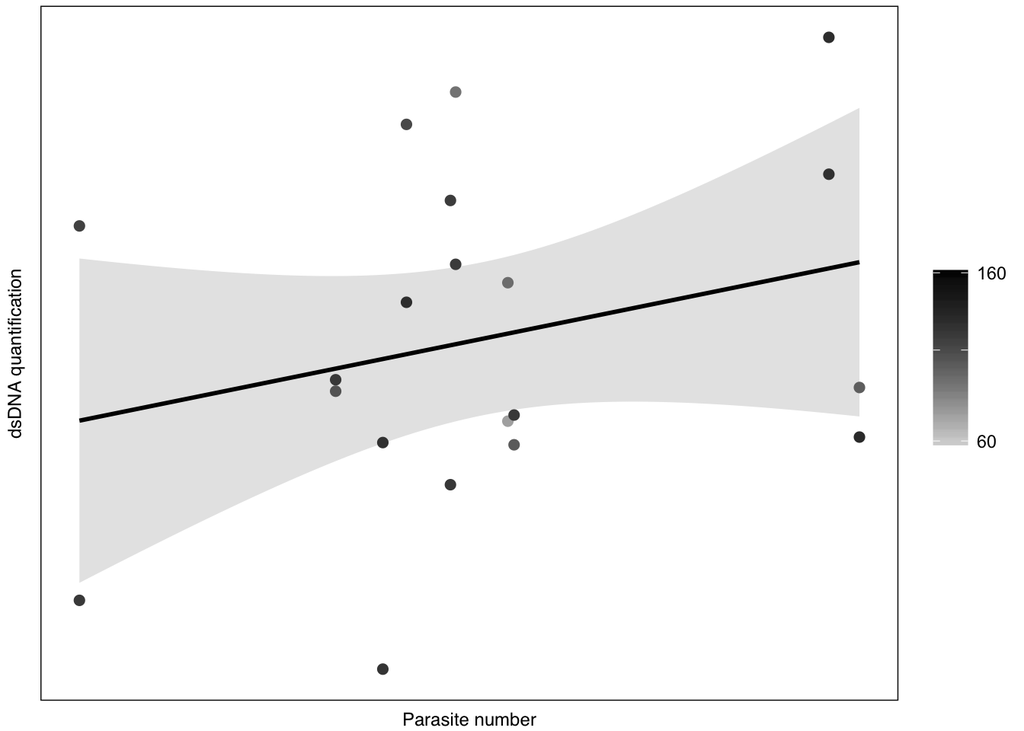

```r
raw1 = prep_raw(raw_file_comp1)
identifiers = prep_sample_identifiers(raw1)

# process sample data for plotting
df = identifiers[c(3,5,6,8,9),] # keep only protein, dna, parasite measures and IDS

df = as.data.frame(t(df)) # transpose
rownames(df) = df$CLIENT_IDENTIFIER; df$CLIENT_IDENTIFIER = NULL
indx = sapply(df, is.factor); df[indx] = lapply(df[indx], function(x) as.character(x))
df$CLIENT_PROTEIN = as.numeric(df$CLIENT_PROTEIN); df$DSDNA_ASSAY = as.numeric(df$DSDNA_ASSAY)
df$TOTAL_PARASITES = as.numeric(df$TOTAL_PARASITES)

df = merge(df, measured_mets, by = 'row.names'); rownames(df) = df$Row.names; df$Row.names = NULL
colnames(df)[5] = 'measured_mets'

df = mutate(df,
            treated = ifelse(grepl('_UE',df$GROUP_ID),'untreated','treated'),
            group = ifelse(grepl('Res1',df$GROUP_ID),'group 1','group2'))

df = mutate(df,
            measured_mets_scaled = measured_mets/mean(measured_mets),
            CLIENT_PROTEIN_scaled = CLIENT_PROTEIN/mean(CLIENT_PROTEIN),
            TOTAL_PARASITES_scaled = TOTAL_PARASITES/mean(TOTAL_PARASITES))

corr_eqn_r <- function(x,y, digits = 4) { corr_coef = round(cor(x, y), digits = digits)
  paste("italic(r) == ", corr_coef) }
corr_eqn_p <- function(x,y, digits = 4) { p_value = round(cor.test(x,y)$p.value, digits = digits)
  paste("italic(pvalue) == ", format(p_value, scientific=FALSE)) }

# plot parasite #, dna amount, and protein amount NOTE LOG10 AXIS
summary = ggplot(df, aes(x = TOTAL_PARASITES, y = DSDNA_ASSAY)) +
  custom_theme_pca + theme(plot.margin = unit(c(1,1,1,1),"mm"),
                        axis.text.y = element_blank(),
                        axis.ticks = element_blank(),
                        axis.title = element_text(family = "Helvetica")) +
  geom_smooth(colour = "black", fill = "gray", method = "lm") +
  geom_point(size=2, aes(color = CLIENT_PROTEIN)) +
  scale_colour_gradient("Protein \nAmount", low="lightgrey", high="black",
                        breaks = c(50,110,161), limits = c(50,161),
                        labels=c("60","","160")) +
 scale_shape(NULL) +
  scale_y_log10() + scale_x_log10() +
  xlab("Parasite number") + ylab("dsDNA quantification")
summary
```

```r
s = summary + guides(shape = F, color = F)

# ggsave('fig_1c_sample_characteristics_dec2017.pdf', s, width = 1.75, height = 3, units = "in")
df_test = df[,c(1,2,4,5)]; colnames(df_test) = c('protein','dsDNA','parasite count','metabolites')
df_test2 = melt(df_test, id.vars = c('dsDNA'))
plot_final = ggplot(df_test2, aes(x = dsDNA, y = value, color = variable)) + geom_point(size =2) +
  scale_color_manual(values = c("black","darkblue","darkred")) +
  facet_wrap(~variable, scales = "free_y") +
  geom_smooth(fill = "gray", method = "lm") +
  custom_theme_pca + theme(plot.margin = unit(c(1,1,1,1),"mm"),
                           axis.text.y = element_blank(),
                           axis.ticks = element_blank(),
                           axis.title = element_text(family = "Helvetica"),
                           panel.spacing.x = unit(.1, "lines")) +
  xlab("dsDNA") + ylab(NULL) + guides(color = F)

ggsave('march2018_fig2B.pdf',plot_final, height = 3, width = 4, units = "in", useDingbats = F)


# devSVG(file = "fig_1c_sample_characteristics_dec2017.svg", width = 1.75, height = 3, xmlHeader = T)
# s
# dev.off()

rm(raw1,identifiers,df,indx,s,summary,tab)
```

5 Check to see if median and SD scale (Bias requires log transformation)

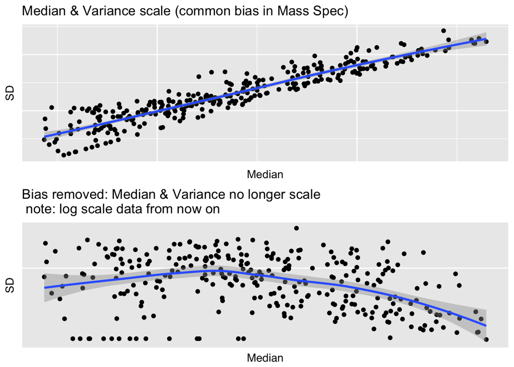

```r
raw1 = prep_raw(raw_file_comp1)
identifiers = prep_sample_identifiers(raw1)
raw2 = remove_NAs(raw1)
raw3 = as.matrix(imputing_missing(raw2,0))

# scale to median (so all metabolite abundances hover around 1)
df = as.data.frame(raw3); df$mets = rownames(df)
df = mutate(df, med = apply(df[,-c(21)],1,median), stand_dev = apply(df[,-c(21)],1,sd))
df2 = df[,c(21:23)] # keep just median and SD

df2= df2[order(df2$med,df2$stand_dev),]
p1 = ggplot(data = df2, aes(x = med, y = stand_dev)) + geom_point() +
  scale_x_log10() + scale_y_log10() + geom_smooth(method = 'loess') +
  xlab('Median') + ylab('SD') +
  theme(axis.text = element_blank(), axis.ticks = element_blank()) +
  ggtitle("Median & Variance scale (common bias in Mass Spec)")

# repeat with logged data
df = as.data.frame(log2(raw3));df$mets = rownames(df)
df = mutate(df, log_med = apply(df[,-c(21)],1,median), log_stand_dev = apply(df[,-c(21)],1,sd))
df2 = df[,c(21:23)] # keep just median and SD

df2= df2[order((df2$log_med),(df2$log_stand_dev)),]
p2 = ggplot(data = df2, aes(x = log_med, y = log_stand_dev)) + geom_point() +
  scale_x_log10() + scale_y_log10() + geom_smooth(method = 'loess') +
  xlab('Median') + ylab('SD') + theme(axis.text = element_blank(), axis.ticks = element_blank(), axis.title = element_text(family = "Helvetica")) +
  ggtitle("Bias removed: Median & Variance no longer scale\n note: log scale data from now on")

grid.newpage()
lay <- rbind(c(1,1),
             c(2,2))
plot_final = grid.arrange(p1,p2,ncol = 1, nrow = 2, layout_matrix = lay)#, widths = 2:2)
```

```r
ggsave('feb3018_suppl1.pdf',plot_final, height = 6, width = 6.875, units = "in")
# devSVG(file = "dec122017_suppl1.svg", width = 6.875, height = 6,xmlHeader = T)
# plot(plot_final)
# dev.off()

rm(df,df2, raw1, raw2, raw3,identifiers)
```

Notes to self: Check Aug1 file for history of changes Aug 9 has correlation plots and exploration of median v mean centering, removal of outliers Oct drops troph stage samples

6 Preprocess data

```r
raw1 = prep_raw(raw_file_comp1) # adjust formating
identifiers = prep_sample_identifiers(raw1) # extract relevant samples
raw_remove_NAs = remove_NAs(raw1) # check no nondetected metabolites due to subset
no_missing_data = imputing_missing(raw_remove_NAs, 0) #imput missing values

labels_clone = c("S1","S1","S1","S1","S1",
            "S1","S1","S1","S1","S1",
            "S2","S2","S2","S2","S2",
            "S2","S2","S2","S2","S2")
labels_drug = c("S1","S1","S1","S1","S1",
            "S2","S2","S2","S2","S2",
            "S1","S1","S1","S1","S1",
            "S2","S2","S2","S2","S2")

# Sample normalization
norm_dna = normalize(no_missing_data,identifiers,"dna") # DNA NORMALIZATION
norm_pro = normalize(no_missing_data,identifiers,"protein") # PROTEIN NORMALIZATION
norm_para = normalize(no_missing_data,identifiers,"para") # PARASITE NUMBER NORMALIZATION

# Feature normalization (log, center, scale)
# log
log_nonorm = log2(no_missing_data)
log_dna = log2(norm_dna)
log_pro = log2(norm_pro)
log_para = log2(norm_para)
# prep format for PCA
data_transposed_unnorm = t(log_nonorm)
data_transposed_dna = t(log_dna)
data_transposed_pro = t(log_pro)
data_transposed_para = t(log_para)
# [median] center & [sd] scale
data_for_pca_unnorm = median_center_scale_data(data_transposed_unnorm)
data_for_pca_dna = median_center_scale_data(data_transposed_dna)
data_for_pca_pro = median_center_scale_data(data_transposed_pro)
data_for_pca_para = median_center_scale_data(data_transposed_para)

rm(raw1,identifiers,raw_remove_NAs,no_missing_data,data_transposed_unnorm,data_transposed_dna,data_transposed_para,data_transposed_pro,log_pro,log_para,log_dna,log_nonorm,norm_para,norm_pro,norm_dna,raw_file_comp1)
```

7 Plot HEPES and Phenol Red boxplots

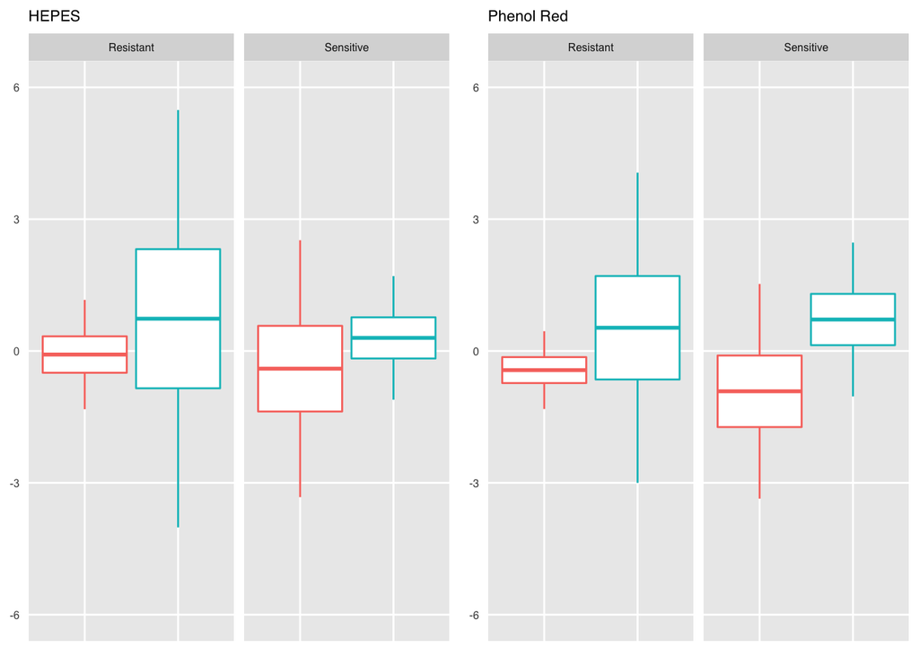

```r
list_o_data = list(data_for_pca_unnorm,data_for_pca_dna,data_for_pca_pro,data_for_pca_para)

for (x in 1:4) {
  data = as.data.frame(list_o_data[[x]])
  if (x == 1) { title = 'Unnormalized'}
  else if (x == 2) {title = 'Normalized to DNA'}
  else if (x == 3) {title = 'Normalized to Protein'}
  else { title = 'Normalized to Parasite Number'}
  p = data %>%
    mutate(group = ifelse(grepl('PUR',rownames(data)),'Sensitive','Resistant'),
           treated = ifelse(grepl('plus',rownames(data)),'treated','untreated')) %>%
    group_by(group, treated) %>%
    summarize(mean=mean(HEPES), sd=sd(HEPES)) %>%
    mutate( grouping = paste(group,treated)) %>%
    ggplot(aes(x = as.factor(grouping), color = treated)) +
    geom_boxplot(aes(
      lower = mean - sd,
      upper = mean + sd,
      middle = mean,
      ymin = mean - 3*sd,
      ymax = mean + 3*sd),
    stat = "identity") + #ggtitle(paste('HEPES abundance, ',title)) +
    ggtitle('HEPES') +
    theme(axis.title.x = element_blank(),
          axis.title.y = element_text(family = "Helvetica"),
          axis.text.x = element_blank(),
          axis.text.y = element_text(size = 6),
          axis.ticks = element_blank(),
          strip.text = element_text(size = 6, family = "Helvetica"),
          title = element_text(size = 7, family = "Helvetica"),
          panel.grid.minor = element_blank()) + guides(color = FALSE) +
    facet_wrap(~group, scales = "free_x") + scale_y_continuous(limits = c(-6, 6))
  #print(p)
  if (x == 1) {p1 = p}}

list_o_data = list(data_for_pca_unnorm,data_for_pca_dna,data_for_pca_pro,data_for_pca_para)
for (x in 1:4) {
  data = as.data.frame(list_o_data[[x]])
  if (x == 1) { title = 'Unnormalized'}
  else if (x == 2) {title = 'Normalized to DNA'}
  else if (x == 3) {title = 'Normalized to Protein'}
  else { title = 'Normalized to Parasite Number'}
  p = data %>%
    mutate(group = ifelse(grepl('PUR',rownames(data)),'Sensitive','Resistant'),
           treated = ifelse(grepl('plus',rownames(data)),'treated','untreated')) %>%
    group_by(group, treated) %>%
    summarize(mean=mean(phenolred), sd=sd(phenolred)) %>%
    mutate( grouping = paste(group,treated)) %>%
    ggplot(aes(x = as.factor(grouping), color = treated)) +
    geom_boxplot(aes(
      lower = mean - sd,
      upper = mean + sd,
      middle = mean,
      ymin = mean - 3*sd,
      ymax = mean + 3*sd),
    stat = "identity") +
    ggtitle('Phenol Red') +
    #ggtitle(paste('Phenol Red abundance, ',title)) +
    theme(axis.title.x = element_blank(),
          axis.title.y = element_text(family = "Helvetica"),
          axis.text.x = element_blank(),
          axis.ticks = element_blank(),
          strip.text = element_text(size = 6),
          title = element_text(size = 7,family = "Helvetica"),
          axis.text.y = element_text(size = 6,family = "Helvetica"),
          panel.grid.minor = element_blank()) + guides(color = FALSE)+
    facet_wrap(~group, scales = "free_x")  + scale_y_continuous(limits = c(-6, 6))
  #print(p)
  if (x == 1) {p2 = p}}

grid.newpage()
lay <- rbind(c(1,2),
             c(1,2))
plot_final = grid.arrange(p1,p2,ncol = 2, nrow = 1, layout_matrix = lay)#, widths = 2:2)
```

```r
ggsave('feb2018_suppl2.pdf',plot_final, width = 2.237, height = 2, units = "in")
# devSVG(file = "dec122017_suppl2.svg", width = 2.237, height = 2, xmlHeader = T)
# plot(plot_final)
# dev.off()

rm(p,x,title,data)
```

8 Plot heatmap of correlation to HEPES and Phenol Red

```r
# HEPES
cor_mat = c(); cor_mat_count = c()
for (x in 1:4) {
  data = as.data.frame(list_o_data[[x]])
  cor_mat_temp = as.data.frame(matrix(NA, nrow = 0, ncol = ncol(data)))
  for (y in 1:ncol(data)) {
    cor_data = cor.test(data$HEPES,data[,y], alternative = c("two.sided"), method = c("pearson"))
    cor_r = cor_data$estimate
    cor_p = cor_data$p.value
    colnames(cor_mat_temp)[y] = colnames(data)[y]
    cor_mat_temp[1,y] = cor_r
    cor_mat_temp[2,y] = cor_p }
  cor_mat_temp[2,] = p.adjust(cor_mat_temp[2,], method = "fdr")
  for (i in 1:ncol(cor_mat_temp)) {
    if (cor_mat_temp[2,i] > 0.05) {
      cor_mat_temp[2,i] = NA; cor_mat_temp[1,i] = NA } # if significant p value
    else if (abs(cor_mat_temp[1,i]) < 0.5) {
      cor_mat_temp[2,i] = NA; cor_mat_temp[1,i] = NA } } # if notable correlation coefficient
  cor_mat[[x]] = cor_mat_temp
  cor_mat_count[[x]] = cor_mat_temp[colSums(!is.na(cor_mat_temp)) > 0] }

rm(x,y,cor_p,cor_r,cor_mat_temp,cor_data)

for (x in 1:4) {
      # prep labels
  if (x == 1) {
    title = 'Unnormalized'; title2 = 'unnorm_'
  } else if (x == 2) {
    title = 'Normalized to DNA'
    title2 = 'dna_norm_'
  } else if (x == 3) {
    title = 'Normalized to Protein'
    title2 = 'pro_norm_'
  } else {
    title = 'Normalized to Parasite Number'
    title2 = 'para_norm_'
  }
  print(paste(title, '- mets correlated to HEPES'))
  print(dim(cor_mat_count[[x]])[2])}
```

```
## [1] "Unnormalized - mets correlated to HEPES"
## [1] 76
## [1] "Normalized to DNA - mets correlated to HEPES"
## [1] 27
## [1] "Normalized to Protein - mets correlated to HEPES"
## [1] 187
## [1] "Normalized to Parasite Number - mets correlated to HEPES"
## [1] 235
```

```r
heatmap_matrix = as.data.frame(matrix(NA, nrow = 0, ncol = ncol(cor_mat[[2]])))
for (x in 1:4) {
    if (x == 1) {
      title = ' Unnormalized'
    } else if (x == 2) {
      title = 'DNA'
    } else if (x == 3) {
      title = 'Protein'
    } else {
      title = 'Parasite Number' }
  df = as.data.frame(cor_mat[[x]][1,])
  heatmap_matrix = rbind(heatmap_matrix,df)
  rownames(heatmap_matrix)[x] = title
}
df = heatmap_matrix %>% mutate(norm_approach = rownames(heatmap_matrix)) %>% melt(id.vars = c("norm_approach"))

mets_to_correct_prep = df[df$norm_approach == ' Unnormalized',]
mets_to_correct_hepes = unique(mets_to_correct_prep[(mets_to_correct_prep$value) > 0.5,2])
count_cor = df[!is.na(df$value),]; table(count_cor$norm_approach)
```

```
##
##    Unnormalized             DNA Parasite Number         Protein
##              76              27             235             187
```

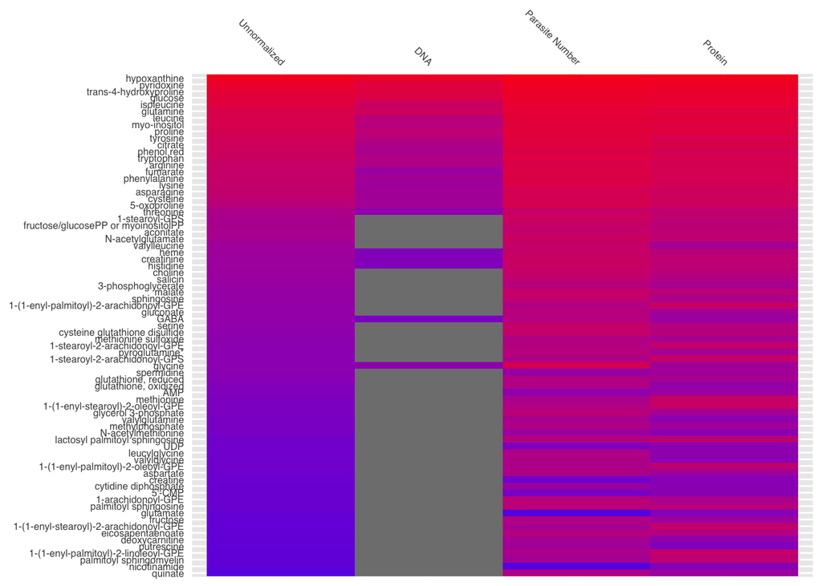

```r
rm(i, mets_to_correct_prep,heatmap_matrix,data,count_cor,cor_mat,cor_mat_count,x,title,title2)

df$variable = sub('Isobar:fructose16-diphosphateglucose16-diphosphatemyo-inositol14or13-diphosphate','fructose/glucosePP or myoinositolPP',df$variable)
df$variable = sub("adenosine5\\'-monophosphate\\(AMP\\)",'AMP',df$variable)
df$variable = sub("cytidine5'-monophosphate\\(5\\'-CMP\\)","5'-CMP",df$variable)
df$variable = sub("uridine5\\'\\-diphosphate\\(UDP\\)",'UDP',df$variable)
df$variable = sub("palmitoylsphingomyelin\\(d18\\:1\\/16\\:0\\)",'palmitoyl sphingomyelin',df$variable)
df$variable = sub("N\\-palmitoyl\\-sphingosine\\(d18\\:1\\/16\\:0\\)",'palmitoyl sphingosine',df$variable)
df$variable = sub("lactosyl\\-N\\-palmitoyl\\-sphingosine",'lactosyl palmitoyl sphingosine',df$variable)
df$variable = sub("glutathioneoxidized\\(GSSG\\)",'glutathione, oxidized',df$variable)
df$variable = sub("glutathionereduced\\(GSH\\)",'glutathione, reduced',df$variable)
df$variable = sub("eicosapentaenoate\\(EPA\\;20\\:5n3\\)",'eicosapentaenoate',df$variable)
df$variable = sub("gamma-aminobutyrate\\(GABA\\)",'GABA',df$variable)
df$variable = sub("1-stearoyl-GPS\\(18\\:0\\)\\*","1-stearoyl-GPS",df$variable)
df$variable = sub("pyridoxine\\(VitaminB6\\)","pyridoxine",df$variable)
df$variable = sub("glycerol3-phosphate","glycerol 3-phosphate",df$variable)
df$variable = sub("phenolred","phenol red",df$variable)
df$variable = sub("aconitate\\[cisortrans\\]","aconitate",df$variable)
df$variable = sub("cytidinediphosphate","cytidine diphosphate",df$variable)
df$variable = sub("methioninesulfoxide","methionine sulfoxide",df$variable)
df$variable = sub("cysteine-glutathionedisulfide","cysteine glutathione disulfide",df$variable)
df$variable = sub("1-stearoyl-2-arachidonoyl-GPS\\(18:0\\/20:4\\)",'1-stearoyl-2-arachidonoyl-GPS',df$variable)
df$variable = sub("1-stearoyl-2-arachidonoyl-GPE\\(18:0/20:4\\)","1-stearoyl-2-arachidonoyl-GPE",df$variable)
df$variable = sub("1-arachidonoyl-GPE\\(20\\:4n6\\)\\*",'1-arachidonoyl-GPE',df$variable)
df$variable = sub("1-\\(1-enyl-stearoyl\\)-2-oleoyl-GPE\\(P-18\\:0\\/18\\:1\\)","1-(1-enyl-stearoyl)-2-oleoyl-GPE",df$variable)
df$variable = sub("1-\\(1-enyl-stearoyl\\)-2-arachidonoyl-GPE\\(P-18:0\\/20:4\\)\\*",'1-(1-enyl-stearoyl)-2-arachidonoyl-GPE',df$variable)
df$variable = sub("1-\\(1-enyl-palmitoyl\\)-2-arachidonoyl-GPE\\(P-16:0\\/20:4\\)\\*",'1-(1-enyl-palmitoyl)-2-arachidonoyl-GPE',df$variable)
df$variable = sub("1-\\(1-enyl-palmitoyl\\)-2-linoleoyl-GPE\\(P-16:0\\/18:2\\)\\*",'1-(1-enyl-palmitoyl)-2-linoleoyl-GPE',df$variable)
df$variable = sub("1-\\(1-enyl-palmitoyl\\)-2-oleoyl-GPE\\(P-16:0\\/18:1\\)\\*",'1-(1-enyl-palmitoyl)-2-oleoyl-GPE',df$variable)

unnorm_only = df[df$norm_approach == ' Unnormalized',]
unnorm_only = na.omit(unnorm_only); unnorm_only = unnorm_only[unnorm_only$value>0.5,]
unnorm_only = unnorm_only[unnorm_only$variable != "HEPES",]

unnorm_cluster = as.data.frame(unnorm_only[,c(2,3)]); rownames(unnorm_cluster) = unnorm_cluster$variable
order_mets = unnorm_cluster[order(unnorm_cluster$value),1]

df2 = subset(df, df$variable %in% unnorm_only$variable)
df2 = df2 %>% mutate(variable = factor(variable),
                     variable = factor(variable, levels = (order_mets)))
x = ggplot(df2) + geom_tile(aes(x = as.factor(variable), y = norm_approach, fill = value))+
  scale_fill_gradientn(limits = c(0,1),
  colours=c("navyblue", "blue", "red"),
  breaks=c(0,0.9,1), labels=format(c(0,0.9,1))) + coord_flip() +
  theme(axis.text.x = element_text(size = 6, angle = -45, hjust = 1, vjust = 1, family = "Helvetica"),
        axis.text.y = element_text(size = 6,family = "Helvetica"),
        axis.ticks = element_blank(),
        axis.title = element_blank()) +
  ggtitle(NULL) + guides(fill = FALSE) + scale_y_discrete(position = "top")
x
```

```r
ggsave('fig_Xb_feb2018.pdf', x, width = 2.4, height = 7, units = "in")
# devSVG(file = "fig_Xb_dec2017.svg", width = 2.4, height = 7, xmlHeader = T)
# x
# dev.off()

rm(unnorm_only,df)
#Def need to filter because peaks are maintained from unnorm to everything else

# PHENOL RED
cor_mat = c(); cor_mat_count = c()
for (x in 1:4) {
  data = as.data.frame(list_o_data[[x]])
  cor_mat_temp = as.data.frame(matrix(NA, nrow = 0, ncol = ncol(data)))
  for (y in 1:ncol(data)) {
    cor_data = cor.test(data$phenolred,data[,y], alternative = c("two.sided"), method = c("pearson"))
    cor_r = cor_data$estimate
    cor_p = cor_data$p.value
    colnames(cor_mat_temp)[y] = colnames(data)[y]
    cor_mat_temp[1,y] = cor_r
    cor_mat_temp[2,y] = cor_p }
  cor_mat_temp[2,] = p.adjust(cor_mat_temp[2,], method = "fdr")
  for (i in 1:ncol(cor_mat_temp)) {
    if (cor_mat_temp[2,i] > 0.05) {
      cor_mat_temp[2,i] = NA; cor_mat_temp[1,i] = NA }
    else if (abs(cor_mat_temp[1,i]) < 0.5) {
      cor_mat_temp[2,i] = NA; cor_mat_temp[1,i] = NA } }
  cor_mat[[x]] = cor_mat_temp
  cor_mat_count[[x]] = cor_mat_temp[colSums(!is.na(cor_mat_temp)) > 0] }

rm(x,y,cor_p,cor_r,cor_mat_temp,cor_data)

for (x in 1:4) {
      # prep labels
  if (x == 1) {
    title = ' Unnormalized'; title2 = 'unnorm_'
  } else if (x == 2) {
    title = 'Normalized to DNA'
    title2 = 'dna_norm_'
  } else if (x == 3) {
    title = 'Normalized to Protein'
    title2 = 'pro_norm_'
  } else {
    title = 'Normalized to Parasite Number'
    title2 = 'para_norm_'
  }
  print(paste(title, '- mets correlated to Phenol Red'))
  print(dim(cor_mat_count[[x]])[2])}
```

```
## [1] " Unnormalized - mets correlated to Phenol Red"
## [1] 82
## [1] "Normalized to DNA - mets correlated to Phenol Red"
## [1] 35
## [1] "Normalized to Protein - mets correlated to Phenol Red"
## [1] 141
## [1] "Normalized to Parasite Number - mets correlated to Phenol Red"
## [1] 197
```

```r
heatmap_matrix = as.data.frame(matrix(NA, nrow = 0, ncol = ncol(cor_mat[[2]])))
for (x in 1:4) {
    if (x == 1) {
      title = ' Unnormalized'
    } else if (x == 2) {
      title = 'DNA'
    } else if (x == 3) {
      title = 'Protein'
    } else {
      title = 'ParasiteNumber' }
  df = as.data.frame(cor_mat[[x]][1,])
  heatmap_matrix = rbind(heatmap_matrix,df)
  rownames(heatmap_matrix)[x] = title
}
df = heatmap_matrix %>% mutate(norm_approach = rownames(heatmap_matrix)) %>% melt(id.vars = c("norm_approach"))

mets_to_correct_prep_pr = df[df$norm_approach == ' Unnormalized',]
mets_to_correct_phenolred = unique(mets_to_correct_prep_pr[(mets_to_correct_prep_pr$value) > 0.5,2])
count_cor = df[!is.na(df$value),]; table(count_cor$norm_approach)
```

```
##
##   Unnormalized            DNA ParasiteNumber        Protein
##             82             35            197            141
```

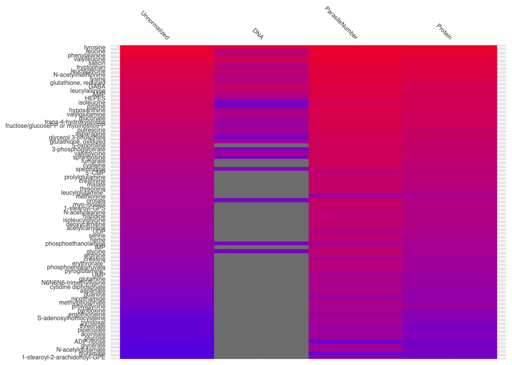

```r
rm(i,heatmap_matrix,data,count_cor,cor_mat,cor_mat_count,x,title,title2)

df$variable = sub('Isobar:fructose16-diphosphateglucose16-diphosphatemyo-inositol14or13-diphosphate','fructose/glucosePP or myoinositolPP',df$variable)
df$variable = sub("adenosine5\\'-monophosphate\\(AMP\\)",'AMP',df$variable)
df$variable = sub("cytidine5'-monophosphate\\(5\\'-CMP\\)","5'-CMP",df$variable)
df$variable = sub("uridine5\\'\\-diphosphate\\(UDP\\)",'UDP',df$variable)
df$variable = sub("palmitoylsphingomyelin\\(d18\\:1\\/16\\:0\\)",'palmitoyl sphingomyelin',df$variable)
df$variable = sub("N\\-palmitoyl\\-sphingosine\\(d18\\:1\\/16\\:0\\)",'palmitoyl sphingosine',df$variable)
df$variable = sub("lactosyl\\-N\\-palmitoyl\\-sphingosine",'lactosyl palmitoyl sphingosine',df$variable)
df$variable = sub("glutathioneoxidized\\(GSSG\\)",'glutathione, oxidized',df$variable)
df$variable = sub("glutathionereduced\\(GSH\\)",'glutathione, reduced',df$variable)
df$variable = sub("eicosapentaenoate\\(EPA\\;20\\:5n3\\)",'eicosapentaenoate',df$variable)
df$variable = sub("gamma-aminobutyrate\\(GABA\\)",'GABA',df$variable)
df$variable = sub("1-stearoyl-GPS\\(18\\:0\\)\\*","1-stearoyl-GPS",df$variable)
df$variable = sub("pyridoxine\\(VitaminB6\\)","pyridoxine",df$variable)
df$variable = sub("glycerol3-phosphate","glycerol 3-phosphate",df$variable)
df$variable = sub("phenolred","phenol red",df$variable)
df$variable = sub("aconitate\\[cisortrans\\]","aconitate",df$variable)
df$variable = sub("cytidinediphosphate","cytidine diphosphate",df$variable)
df$variable = sub("methioninesulfoxide","methionine sulfoxide",df$variable)
df$variable = sub("cysteine-glutathionedisulfide","cysteine glutathione disulfide",df$variable)
df$variable = sub("1-stearoyl-2-arachidonoyl-GPS\\(18:0\\/20:4\\)",'1-stearoyl-2-arachidonoyl-GPS',df$variable)
df$variable = sub("1-stearoyl-2-arachidonoyl-GPE\\(18:0/20:4\\)","1-stearoyl-2-arachidonoyl-GPE",df$variable)
df$variable = sub("1-arachidonoyl-GPE\\(20\\:4n6\\)\\*",'1-arachidonoyl-GPE',df$variable)
df$variable = sub("1-\\(1-enyl-stearoyl\\)-2-oleoyl-GPE\\(P-18\\:0\\/18\\:1\\)","1-(1-enyl-stearoyl)-2-oleoyl-GPE",df$variable)
df$variable = sub("1-\\(1-enyl-stearoyl\\)-2-arachidonoyl-GPE\\(P-18:0\\/20:4\\)\\*",'1-(1-enyl-stearoyl)-2-arachidonoyl-GPE',df$variable)
df$variable = sub("1-\\(1-enyl-palmitoyl\\)-2-arachidonoyl-GPE\\(P-16:0\\/20:4\\)\\*",'1-(1-enyl-palmitoyl)-2-arachidonoyl-GPE',df$variable)
df$variable = sub("1-\\(1-enyl-palmitoyl\\)-2-linoleoyl-GPE\\(P-16:0\\/18:2\\)\\*",'1-(1-enyl-palmitoyl)-2-linoleoyl-GPE',df$variable)
df$variable = sub("1-\\(1-enyl-palmitoyl\\)-2-oleoyl-GPE\\(P-16:0\\/18:1\\)\\*",'1-(1-enyl-palmitoyl)-2-oleoyl-GPE',df$variable)
df$variable = sub("phosphoenolpyruvate\\(PEP\\)",'phosphoenolpyruvate',df$variable)
df$variable = sub("adenosine5\\'-diphosphoribose\\(ADP-ribose\\)",'ADP-ribose',df$variable)
df$variable = sub("uridine5\\'-monophosphate\\(UMP\\)",'UMP',df$variable)
df$variable = sub("S-adenosylhomocysteine\\(SAH\\)",'S-adenosylhomocysteine',df$variable)
df$variable = sub("inosine5\\'-monophosphate\\(IMP\\)",'IMP',df$variable)

unnorm_only = df[df$norm_approach == ' Unnormalized',]; unnorm_only = na.omit(unnorm_only); unnorm_only = unnorm_only[unnorm_only$value>0.5,];
unnorm_only = unnorm_only[unnorm_only$variable != "phenol red",]

unnorm_cluster = as.data.frame(unnorm_only[,c(2,3)]); rownames(unnorm_cluster) = unnorm_cluster$variable
order_mets = unnorm_cluster[order(unnorm_cluster$value),1]

df2 = subset(df, df$variable %in% unnorm_only$variable)
df2 = df2 %>% mutate(variable = factor(variable),
                     variable = factor(variable, levels = (order_mets)))
x = ggplot(df2) + geom_tile(aes(x = as.factor(variable), y = norm_approach, fill = value))+
  scale_fill_gradientn(limits = c(0,1),
  colours=c("navyblue", "blue", "red"),
  breaks=c(0,0.9,1), labels=format(c(0,0.9,1))) + coord_flip() +
  theme(axis.text.x = element_text(size = 6, angle = -45, hjust = 1, vjust = 1,family = "Helvetica"),
        axis.text.y = element_text(size = 6,family = "Helvetica"),
        axis.ticks = element_blank(),
        axis.title = element_blank()) +
  ggtitle(NULL) + guides(fill = FALSE) + scale_y_discrete(position = "top")
x
```

```r
ggsave('fig_2e_feb2018.pdf', x, width = 2.4, height = 7, units = "in")
# devSVG(file = "fig_2e_dec2017.svg", width = 2.4, height = 7, xmlHeader = T)
# x
# dev.off()

rm(unnorm_only,df, mets_to_correct_prep_pr)
```

10 Princple Component Analysis without NORMALIZATION

```r
pca_data <- prcomp(data_for_pca_unnorm, center = F, scale. = F)
summary(pca_data)
```

```
## Importance of components:
##                           PC1    PC2     PC3     PC4     PC5     PC6
## Standard deviation     9.9821 7.0538 5.33982 5.05157 4.45226 3.99048
## Proportion of Variance 0.3068 0.1532 0.08778 0.07856 0.06103 0.04902
## Cumulative Proportion  0.3068 0.4599 0.54772 0.62628 0.68731 0.73633
##                            PC7     PC8     PC9    PC10    PC11    PC12
## Standard deviation     3.77052 3.61219 2.95498 2.86462 2.59860 2.40524
## Proportion of Variance 0.04377 0.04017 0.02688 0.02526 0.02079 0.01781
## Cumulative Proportion  0.78010 0.82027 0.84715 0.87241 0.89320 0.91101
##                           PC13    PC14    PC15    PC16    PC17    PC18
## Standard deviation     2.28263 2.13634 2.01220 1.93154 1.84436 1.73302
## Proportion of Variance 0.01604 0.01405 0.01247 0.01149 0.01047 0.00925
## Cumulative Proportion  0.92705 0.94110 0.95357 0.96505 0.97552 0.98477
##                           PC19    PC20
## Standard deviation     1.61887 1.52520
## Proportion of Variance 0.00807 0.00716
## Cumulative Proportion  0.99284 1.00000
```

```r
data_plot = data.frame(pca_data$x[,c(1,2)]) # Adjust for plotting

metadata = as.data.frame(rownames(pca_data$x)) %>%
    mutate(sample = rownames(pca_data$x), treatment = ifelse(grepl('minus',sample),"untreated","treated"),
           clone = ifelse(grepl('BAT',sample),"resistant","sensitive")); metadata[,1] = NULL

t = adonis(data_plot ~ treatment*clone, data = metadata, method = "eu") # PerMANOVA
print(t)
```

```
##
## Call:
## adonis(formula = data_plot ~ treatment * clone, data = metadata,      method = "eu")
##
## Permutation: free
## Number of permutations: 999
##
## Terms added sequentially (first to last)
##
##                 Df SumsOfSqs MeanSqs F.Model      R2 Pr(>F)
## treatment        1    351.50  351.50 2.67768 0.13635  0.094 .
## clone            1    109.79  109.79 0.83633 0.04259  0.405
## treatment:clone  1     16.33   16.33 0.12443 0.00634  0.883
## Residuals       16   2100.35  131.27         0.81473
## Total           19   2577.97                 1.00000
## ---
## Signif. codes:  0 '***' 0.001 '**' 0.01 '*' 0.05 '.' 0.1 ' ' 1
```

```r
unscaled = qplot(x = PC1, y = PC2, data = data_plot, shape = factor(labels_clone),
                 color = factor(labels_drug),
                 size=I(2), show.legend = FALSE, alpha = .9) +
  custom_theme_pca + scale_shape_manual(values = c(16,17,18,9)) +
  theme(plot.margin = unit(c(1,1,1,0),"mm"), title = element_text(family = "Helvetica"),
        axis.text = element_text(family = "Helvetica")) + # top, right, bottom, and left
  ggtitle("No normalization,\ntreatment p-value = NS\nclone p-value = NS\nboth p-value = NS") + ylab(paste("PC2",get_2nd(pca_data),sep = " ")) + xlab(paste("PC1",get_1st(pca_data),sep = " "))

ggsave('fig_2d_no_norm_jan2018.pdf', unscaled, width = 2.237, height = 2, units = "in")
# devSVG(file = "fig_2d_no_norm_dec2017.svg", width = 2.237, height = 2, xmlHeader = T)
# unscaled
# dev.off()

rotation_a = pca_data$rotation #loadings
# PC 1 loadings (most important variable in PC1 in full dataset without normalization)
t = c(); t$PC1_no_norm = names(tail(sort(abs(rotation_a[,1])),10))
# PC 2 loadings (most important variable in PC2 in full dataset without normalization)
t$PC2_no_norm = names(tail(sort(abs(rotation_a[,2])),10))

rm(pca_data,data_plot,rotation_a,x)
```

11 Now explore normalization methods

```r
# PCA for DNA NORMALIZATION
pca_dna <- prcomp(data_for_pca_dna, center = F, scale. = F)
summary(pca_dna)
```

```
## Importance of components:
##                            PC1    PC2     PC3     PC4     PC5     PC6
## Standard deviation     11.2139 6.7805 4.78252 4.48862 3.65942 3.39822
## Proportion of Variance  0.4133 0.1511 0.07517 0.06621 0.04401 0.03795
## Cumulative Proportion   0.4133 0.5644 0.63954 0.70575 0.74976 0.78771
##                            PC7     PC8     PC9    PC10   PC11    PC12
## Standard deviation     3.10297 2.84227 2.62945 2.50628 2.3469 2.18194
## Proportion of Variance 0.03164 0.02655 0.02272 0.02064 0.0181 0.01565
## Cumulative Proportion  0.81936 0.84591 0.86863 0.88927 0.9074 0.92302
##                           PC13    PC14    PC15    PC16    PC17    PC18
## Standard deviation     2.04283 1.91411 1.82423 1.73883 1.62027 1.55429
## Proportion of Variance 0.01371 0.01204 0.01094 0.00994 0.00863 0.00794
## Cumulative Proportion  0.93674 0.94878 0.95971 0.96965 0.97828 0.98622
##                           PC19   PC20
## Standard deviation     1.49891 1.3953
## Proportion of Variance 0.00738 0.0064
## Cumulative Proportion  0.99360 1.0000
```

```r
data_plot = data.frame(pca_dna$x[,c(1,2)])

t1 = adonis(data_plot ~ treatment*clone, data = metadata, method = "eu") # PerMANOVA
t1
```

```
##
## Call:
## adonis(formula = data_plot ~ treatment * clone, data = metadata,      method = "eu")
##
## Permutation: free
## Number of permutations: 999
##
## Terms added sequentially (first to last)
##
##                 Df SumsOfSqs MeanSqs F.Model      R2 Pr(>F)
## treatment        1     543.3  543.35  4.0974 0.16666  0.036 *
## clone            1     513.2  513.21  3.8701 0.15742  0.040 *
## treatment:clone  1      81.9   81.88  0.6174 0.02511  0.535
## Residuals       16    2121.7  132.61         0.65080
## Total           19    3260.2                 1.00000
## ---
## Signif. codes:  0 '***' 0.001 '**' 0.01 '*' 0.05 '.' 0.1 ' ' 1
```

```r
dna = qplot(x = PC1, y = PC2, data = data_plot, shape = factor(labels_clone),
                 color = factor(labels_drug), size=I(2), show.legend = FALSE, alpha = .9) +
  custom_theme_pca + scale_shape_manual(values = c(16,17,18,9)) +
  theme(plot.margin = unit(c(1,3,1,1),"mm"), title = element_text(family = "Helvetica"),
        axis.text = element_text(family = "Helvetica")) + # top, right, bottom, and left
  ggtitle("Normalization: DNA,\ntreatment p-value < 0.05\nclone p-value < 0.05\nboth p-value = NS") + ylab(paste("PC2",get_2nd(pca_dna),sep = " ")) + xlab(paste("PC1",get_1st(pca_dna),sep = " "))

ggsave('fig_2d_dna_norm_jan2018.pdf', dna,width = 2.237, height = 2, units = "in")
# devSVG(file = "fig_2d_dna_norm_dec2017.svg", width = 2.237, height = 2, xmlHeader = T)
# dna
# dev.off()

rotation_a = pca_dna$rotation #loadings
# PC 1 loadings (most important variable in PC1 in full dataset without normalization)
t$PC1_dna = names(tail(sort(abs(rotation_a[,1])),10))
# PC 2 loadings (most important variable in PC2 in full dataset without normalization)
t$PC2_dna = names(tail(sort(abs(rotation_a[,2])),10))
rm(data_plot,pca_dna, rotation_a)

# Princple Component Analysis for PARASITE NUMBER NORMALIZATION
pca_para <- prcomp(data_for_pca_para, center = F, scale. = F)
summary(pca_para)
```

```
## Importance of components:
##                            PC1    PC2    PC3     PC4     PC5     PC6
## Standard deviation     13.3518 5.5463 3.9789 3.50046 3.31488 3.18930
## Proportion of Variance  0.5821 0.1004 0.0517 0.04001 0.03588 0.03322
## Cumulative Proportion   0.5821 0.6826 0.7343 0.77432 0.81020 0.84342
##                           PC7     PC8     PC9    PC10    PC11    PC12
## Standard deviation     3.0156 2.41531 2.22432 2.09635 1.97484 1.92402
## Proportion of Variance 0.0297 0.01905 0.01616 0.01435 0.01274 0.01209
## Cumulative Proportion  0.8731 0.89216 0.90832 0.92267 0.93540 0.94749
##                          PC13   PC14    PC15    PC16    PC17    PC18
## Standard deviation     1.7150 1.6322 1.49200 1.42953 1.32862 1.28970
## Proportion of Variance 0.0096 0.0087 0.00727 0.00667 0.00576 0.00543
## Cumulative Proportion  0.9571 0.9658 0.97307 0.97974 0.98550 0.99094
##                           PC19    PC20
## Standard deviation     1.21943 1.13514
## Proportion of Variance 0.00486 0.00421
## Cumulative Proportion  0.99579 1.00000
```

```r
data_plot = data.frame(pca_para$x[,c(1,2)])

t2 = adonis(data_plot ~ treatment*clone, data = metadata, method = "eu") # PerMANOVA
t2
```

```
##
## Call:
## adonis(formula = data_plot ~ treatment * clone, data = metadata,      method = "eu")
##
## Permutation: free
## Number of permutations: 999
##
## Terms added sequentially (first to last)
##
##                 Df SumsOfSqs MeanSqs F.Model      R2 Pr(>F)
## treatment        1     254.1  254.13  1.4120 0.06424  0.216
## clone            1     820.9  820.86  4.5609 0.20751  0.036 *
## treatment:clone  1       1.0    1.05  0.0058 0.00026  0.992
## Residuals       16    2879.6  179.98         0.72798
## Total           19    3955.7                 1.00000
## ---
## Signif. codes:  0 '***' 0.001 '**' 0.01 '*' 0.05 '.' 0.1 ' ' 1
```

```r
para = qplot(x = PC1, y = PC2, data = data_plot, shape = factor(labels_clone),
                 color = factor(labels_drug), size=I(2), show.legend = FALSE,  alpha = .9 ) +
  custom_theme_pca + scale_shape_manual(values = c(16,17,18,9)) +
  theme(plot.margin = unit(c(1,1,1,0),"mm"), title = element_text(family = "Helvetica"),
        axis.text = element_text(family = "Helvetica")) +
  ggtitle("Normalization: Parasite number,\ntreatment p-value = NS\nclone p-value < 0.05\nboth p-value = NS") + ylab(paste("PC2",get_2nd(pca_para),sep = " ")) + xlab(paste("PC1",get_1st(pca_para),sep = " "))

ggsave('fig_2d_para_norm_jan2018.pdf', para, width = 2.237, height = 2, units = "in")
# devSVG(file = "fig_2d_para_norm_dec2017.svg", width = 2.237, height = 2, xmlHeader = T)
# para
# dev.off()

rotation_a = pca_para$rotation #loadings
# PC 1 loadings (most important variable in PC1 in full dataset without normalization)
t$PC1_para = names(tail(sort(abs(rotation_a[,1])),10))
# PC 2 loadings (most important variable in PC2 in full dataset without normalization)
t$PC2_para = names(tail(sort(abs(rotation_a[,2])),10))

rm(data_plot,pca_para,rotation_a)

# Princple Component Analysis for PROTEIN NORMALIZATION
pca_pro <- prcomp(data_for_pca_pro, center = F, scale. = F)
summary(pca_pro)
```

```
## Importance of components:
##                            PC1    PC2    PC3     PC4     PC5     PC6
## Standard deviation     11.3079 6.4993 5.0033 4.47883 4.20707 3.61280
## Proportion of Variance  0.3974 0.1313 0.0778 0.06234 0.05501 0.04057
## Cumulative Proportion   0.3974 0.5287 0.6065 0.66883 0.72384 0.76440
##                            PC7     PC8     PC9    PC10    PC11    PC12
## Standard deviation     3.52917 3.44033 2.78291 2.61310 2.44747 2.35115
## Proportion of Variance 0.03871 0.03678 0.02407 0.02122 0.01862 0.01718
## Cumulative Proportion  0.80311 0.83989 0.86396 0.88518 0.90380 0.92098
##                           PC13    PC14    PC15    PC16    PC17    PC18
## Standard deviation     2.11952 1.98854 1.90551 1.81888 1.74220 1.60954
## Proportion of Variance 0.01396 0.01229 0.01128 0.01028 0.00943 0.00805
## Cumulative Proportion  0.93494 0.94723 0.95852 0.96880 0.97823 0.98628
##                           PC19    PC20
## Standard deviation     1.55256 1.41516
## Proportion of Variance 0.00749 0.00622
## Cumulative Proportion  0.99378 1.00000
```

```r
data_plot = data.frame(pca_pro$x[,c(1,2)])


t3 = adonis(data_plot ~ treatment*clone, data = metadata, method = "eu") # PerMANOVA
t3
```

```
##
## Call:
## adonis(formula = data_plot ~ treatment * clone, data = metadata,      method = "eu")
##
## Permutation: free
## Number of permutations: 999
##
## Terms added sequentially (first to last)
##
##                 Df SumsOfSqs MeanSqs F.Model      R2 Pr(>F)
## treatment        1    379.19  379.19 2.62576 0.12908  0.106
## clone            1    232.67  232.67 1.61114 0.07920  0.206
## treatment:clone  1     15.23   15.23 0.10547 0.00518  0.875
## Residuals       16   2310.57  144.41         0.78654
## Total           19   2937.65                 1.00000
```

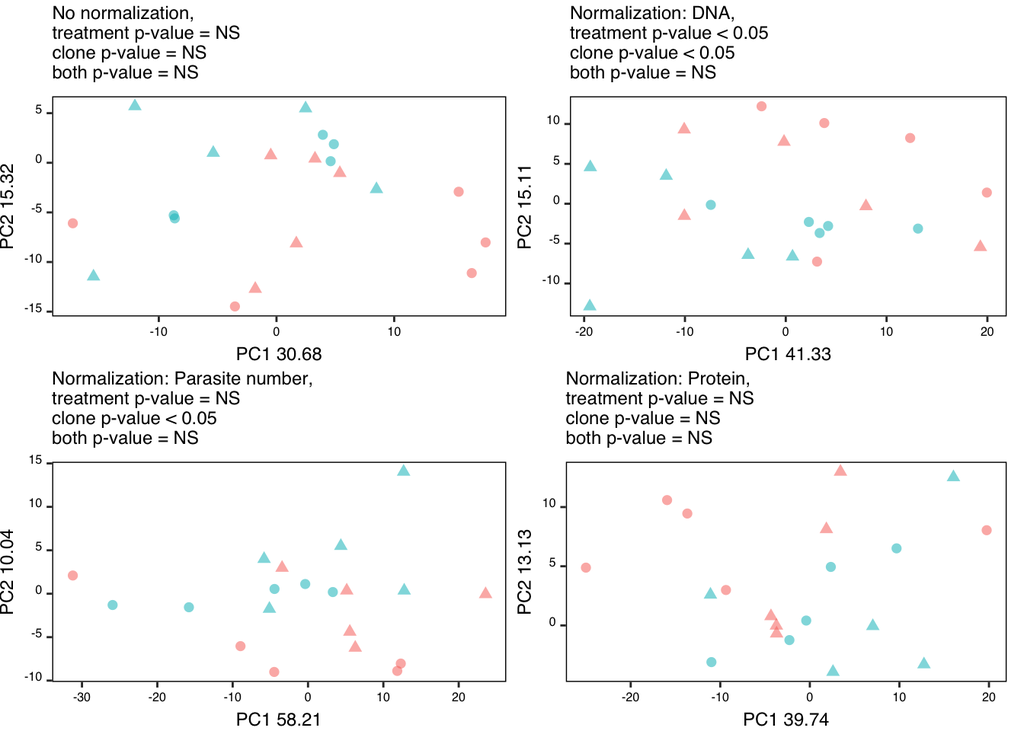

```r
pro = qplot(x = PC1, y = PC2, data = data_plot, shape = factor(labels_clone),
                 color = factor(labels_drug), size=I(2), show.legend = F,  alpha = .9 ) +
  custom_theme_pca + scale_shape_manual(values = c(16,17,18,9))+
  theme(plot.margin = unit(c(1,3,1,1),"mm"), title = element_text(family = "Helvetica"),
        axis.text = element_text(family = "Helvetica")) +
  ggtitle("Normalization: Protein,\ntreatment p-value = NS\nclone p-value = NS\nboth p-value = NS") + ylab(paste("PC2",get_2nd(pca_pro),sep = " ")) + xlab(paste("PC1",get_1st(pca_pro),sep = " "))

ggsave('fig_2d_pro_norm_Feb2018.pdf', pro, width = 2.237, height = 2, units = "in")
# devSVG(file = "fig_2d_pro_norm_dec2017.svg", width = 2.237, height = 2, xmlHeader = T)
# pro
# dev.off()

rotation_a = pca_pro$rotation #loadings
# PC 1 loadings (most important variable in PC1 in full dataset without normalization)
t$PC1_pro = names(tail(sort(abs(rotation_a[,1])),10))
# PC 2 loadings (most important variable in PC2 in full dataset without normalization)
t$PC2_pro = names(tail(sort(abs(rotation_a[,2])),10))

rm(rotation_a,data_plot,pca_pro)

# save plot
print(multiplot(unscaled,para,dna,pro,cols = 2))
```

```r
tiff(filename = "2abcd_pca_multi_panel_jan2018.tiff", width = 4.475, height = 5,
     units = "in", res = 300)
# devSVG(file = "2abcd_pca_multi_panel_dec2017.svg", width = 4.475, height = 5, xmlHeader = T)
# multiplot(unscaled,para,dna,pro,cols = 2)
# dev.off()

# save loadings
write.table(as.data.frame(t), "PC_list_Feb2018.csv", sep = ',',col.names = T, row.names = F)
```

13 Attempt correction for metabolites correlated with HEPES or Phenol Red

```r
#mets_to_correct = intersect(mets_to_correct_hepes,mets_to_correct_phenolred)
mets_to_correct = mets_to_correct_phenolred

corrected_dna_norm = as.data.frame(data_for_pca_dna)
for (x in 1:ncol(corrected_dna_norm)) {
  if (colnames(corrected_dna_norm)[x] %in% mets_to_correct) {
    for (i in 1:nrow(corrected_dna_norm)) {
      corrected_dna_norm[i,x] = NA
      } } }
corrected_dna_norm2 = corrected_dna_norm[colSums(!is.na(corrected_dna_norm)) > 0]

pca_hepes <- prcomp(corrected_dna_norm2, center = F, scale. = F)
summary(pca_hepes)
```

```
## Importance of components:
##                            PC1     PC2    PC3     PC4     PC5     PC6
## Standard deviation     10.6878 4.35336 3.8077 3.50212 2.99664 2.84973
## Proportion of Variance  0.5168 0.08575 0.0656 0.05549 0.04063 0.03674
## Cumulative Proportion   0.5168 0.60258 0.6682 0.72367 0.76430 0.80105
##                            PC7     PC8     PC9    PC10   PC11   PC12
## Standard deviation     2.46321 2.30006 2.19162 2.05933 1.9382 1.9156
## Proportion of Variance 0.02745 0.02394 0.02173 0.01919 0.0170 0.0166
## Cumulative Proportion  0.82850 0.85244 0.87417 0.89335 0.9103 0.9270
##                           PC13    PC14    PC15    PC16    PC17    PC18
## Standard deviation     1.76410 1.61258 1.54372 1.44333 1.39000 1.25316
## Proportion of Variance 0.01408 0.01177 0.01078 0.00943 0.00874 0.00711
## Cumulative Proportion  0.94104 0.95280 0.96358 0.97301 0.98175 0.98886
##                           PC19    PC20
## Standard deviation     1.16250 1.05436
## Proportion of Variance 0.00611 0.00503
## Cumulative Proportion  0.99497 1.00000
```

```r
data_plot = data.frame(pca_hepes$x[,c(1,2)])

t4 = adonis(data_plot ~ treatment*clone, data = metadata, method = "eu") # PerMANOVA
t4
```

```
##
## Call:
## adonis(formula = data_plot ~ treatment * clone, data = metadata,      method = "eu")
##
## Permutation: free
## Number of permutations: 999
##
## Terms added sequentially (first to last)
##
##                 Df SumsOfSqs MeanSqs F.Model      R2 Pr(>F)
## treatment        1    420.93  420.93  4.4721 0.16717  0.034 *
## clone            1    522.21  522.21  5.5481 0.20739  0.018 *
## treatment:clone  1     68.95   68.95  0.7325 0.02738  0.443
## Residuals       16   1505.98   94.12         0.59807
## Total           19   2518.07                 1.00000
## ---
## Signif. codes:  0 '***' 0.001 '**' 0.01 '*' 0.05 '.' 0.1 ' ' 1
```

```r
PR = qplot(x = PC1, y = PC2, data = data_plot, shape = factor(labels_clone),
                 color = factor(labels_drug), size=I(2), show.legend = F,  alpha = .9 ) +
  custom_theme_pca + scale_shape_manual(values = c(16,17,18,9))+
  theme(plot.margin = unit(c(1,2,1,1),"mm"), title = element_text(family = "Helvetica"),
        axis.text = element_text(family = "Helvetica")) +
  ggtitle("Normalization: DNA/Phenol Red,\ntreatment p-value < 0.05\nclone p-value < 0.05\nboth p-value = NS") + ylab(paste("PC2",get_2nd(pca_hepes),sep = " ")) + xlab(paste("PC1",get_1st(pca_hepes),sep = " "))

ggsave('fig_2f_2018.pdf', PR, width = 2.237, height = 2, units = "in")
# devSVG(file = "fig_2f_2017.svg", width = 2.237, height = 2, xmlHeader = T)
# PR
# dev.off()

# print(multiplot(unscaled,dna,para,pro,hepes2, cols = 5))
rm(unscaled,dna,para,pro,t,pca_hepes,mets_to_correct_hepes,mets_to_correct_phenolred,corrected_dna_norm,data_plot)
```

14 Calculate FC

```r
data_list = c(t(data_for_pca_unnorm),t(data_for_pca_dna),t(data_for_pca_para),t(data_for_pca_pro),t(corrected_dna_norm2)) # metabolites as rows again
for (x in 1:5) {
  # calculate SD and mean
  data = data_list[[x]]
  j = nrow(data)
  data2 = as.data.frame(rbind(data,c(rep(-10,5),rep(10,5),rep(-20,5),rep(20,5)))) # groups
  j = nrow(data2); data2 = make_numeric(data2)
  data3 = mutate(data2, met = rownames(data2),
                 met_sd_group1_minus = apply(data2[,data2[j,] == -10], 1, sd), # SD
                 met_mean_group1_minus = rM(data2[,data2[j,] == -10]),
                 met_sd_group2_minus = apply(data2[,data2[j,] == -20], 1, sd ), # SD
                 met_mean_group2_minus = rM(data2[,data2[j,] == -20]),
                 met_sd_group1_plus = apply(data2[,data2[j,] == 10], 1, sd), # SD
                 met_mean_group1_plus = rM(data2[,data2[j,] == 10]),
                 met_sd_group2_plus = apply(data2[,data2[j,] == 20], 1, sd ), # SD
                 met_mean_group2_plus = rM(data2[,data2[j,] == 20]))
  # calc FC and signficance
  fc_data = data3
  #fc_data = mutate(data3,fc = met_mean_group1/met_mean_group2)
  j = nrow(fc_data); fc_data$pval[j] = NA
  for (i in 1:(j-1)) {
    val = as.vector(as.numeric(fc_data[i,c(1:20)]))
    i_result = aov(val ~as.factor(as.character(fc_data[j,c(1:20)])), data = fc_data)  # ANOVA
    fc_data$pval[i] = summary(i_result)[[1]][["Pr(>F)"]][[1]]} # UNCORRECTED

  # Multiple testing correction
  fc_data = mutate(fc_data, adj_pval = p.adjust(fc_data$pval, method = "fdr"))

  # significant comparisons
  significant = subset(fc_data, fc_data$adj_pval <0.05)

  write.table(significant,"fc_G1_v_G2_feb2018_log.csv",sep = ',',col.names = T,row.names = T)

  if (dim(significant)[1] >= 1) {
    hi = ggplot(data = significant) + geom_histogram(aes(significant$fc), bins = 100) +
      #geom_vline(xintercept = 2, color = "red", size = 2) +
      custom_theme2 + xlab("Fold Change") + ylab(NULL)
    # print(hi)
    # ggsave('distribution_FC_dec2017.pdf',hi,width = 3,height = 3)
    rm(hi)}
  else {print('this comparison has no significantly differentially abundant metabolites')}}
```

```
## [1] "this comparison has no significantly differentially abundant metabolites"
## [1] "this comparison has no significantly differentially abundant metabolites"
## [1] "this comparison has no significantly differentially abundant metabolites"
## [1] "this comparison has no significantly differentially abundant metabolites"
## [1] "this comparison has no significantly differentially abundant metabolites"
```

```r
rm(significant,i,i_result,j,data,data2,data3,fc_data,x)
```

15 Comparison 2: Process blood batch data

```r
blood_batch = read.table("/Users/maureencarey/local_documents/work/metabolomics_methods/data/blood_batch_data.csv",sep = ',', header = T)
blood_batch = blood_batch[-c(1:15),]; rownames(blood_batch) = NULL
blood_batch$GROUP_NUMBER = sapply(blood_batch$GROUP_NUMBER, function(x) {gsub("(-)", "_minus", x,fixed = TRUE)})
blood_batch$GROUP_NUMBER = sapply(blood_batch$GROUP_NUMBER, function(x) {gsub("(+)", "_plus", x,fixed = TRUE)})
blood_batch$GROUP_NUMBER = sapply(blood_batch$GROUP_NUMBER, function(x) {gsub("-", "_", x,fixed = TRUE)})
blood_batch$GROUP_NUMBER = sapply(blood_batch$GROUP_NUMBER, function(x) {gsub(" ", "", x,fixed = TRUE)})

rownames(blood_batch) = blood_batch$GROUP_NUMBER
#data = as.data.frame(merge(blood_batch, data_for_pca_dna_comp2, by = 'row.names'))

data_list = list(data_for_pca_unnorm,data_for_pca_dna,data_for_pca_para,data_for_pca_pro, corrected_dna_norm2)
use_for_pca = c()

for (x in 1:5) {
  data = as.data.frame(merge(blood_batch, data_list[[x]], by = 'row.names'))
  rownames(data) = data$Row.names;  data = data[,-c(1:3,5)]; colnames(data)[1] = 'blood'
  use_for_pca[[x]] = make_numeric(as.data.frame(data))
  use_for_pca[[x]]$blood = as.factor(as.character(use_for_pca[[x]]$blood)) }
```

16 PCA blood batch

```r
for (x in 1:5) {
  # prep labels
  if (x == 1) {
    title = 'Unnormalized'; title2 = 'unnorm_'
  } else if (x == 2) {
    title = 'Normalized to DNA'
    title2 = 'dna_norm_'
  } else if (x == 3) {
    title = 'Normalized to Protein'
    title2 = 'pro_norm_'
  } else if (x == 4 ) {
    title = 'Normalized to Parasite Number'
    title2 = 'para_norm_'
  } else {
    title = ' Normalized to DNA and HEPES'
    title2 = 'dna_HEPES_norm_' }

  labels_unique = rownames(use_for_pca[[x]]); substring(labels_unique, 5, 5) = "_"
  labels_blood_batch = use_for_pca[[x]]$blood

  labels_drug = lapply(rownames(use_for_pca[[x]]),
                      function(x) {substr(x,nchar(x)-4,nchar(x))})
  labels_drug = unlist(labels_drug)
  labels_drug = ifelse(labels_drug == '_plus','plus','minus')

  # pca
  pca_dna <- prcomp(use_for_pca[[x]][,-c(1)], center = F, scale. = F)
  summary(pca_dna)

  data_plot = data.frame(pca_dna$x[,c(1:4)])
  # extra = ggplot(data_plot, aes(x = PC1, y = PC2)) +
  #   geom_point(aes(color = factor(labels_blood_batch),
  #                  shape = factor(labels_unique)),
  #             size=I(4), alpha = .9) +
  #   custom_theme3 +
  #   scale_shape_manual(values = c(15:18)) +
  #   theme(plot.margin = unit(c(1,6,6,6),"mm"), # top, right, bottom, and left
  #        legend.title = element_text(size = 12)) +
  #   guides(color = guide_legend(title = 'Blood Batch'),
  #          shape = guide_legend(title = 'Parasite with drug')) +
  #   ggtitle(paste(title," blood batch v drug treatment")) + ylab("PC2") + xlab("PC1")
  # extra

  # fig_for_viewing = ggplot(data_plot, aes(x = PC1, y = PC2)) +
  #   geom_point(aes(color = factor(labels_blood_batch),
  #             shape = factor(labels_drug)),
  #              size=I(2), alpha = .9) +
  #   scale_shape_manual(values = c(15:16)) +
  #   custom_theme3 + theme( plot.margin = unit(c(1,1,1,1),"mm"),
  #                         legend.title=element_text(size = 8),
  #                         legend.text=element_text(size = 6),
  #                         legend.key = element_rect(fill = NA),
  #                         legend.key.height = unit(4, "mm"),
  #                         legend.key.width = unit(2, "mm"),
  #                         legend.position = "bottom",
  #                         legend.direction = 'vertical') +
  #   guides(color = guide_legend(title = 'Blood\nBatch'),
  #         shape = guide_legend(title = 'Parasite\nwith drug')) +
  #   ggtitle(paste(title," blood batch v drug treatment")) +
  #  ylab("PC2") + xlab("PC1")
  # print(fig_for_viewing)

  fig = ggplot(data_plot, aes(x = PC1, y = PC2)) +
    geom_point(aes(color = factor(labels_blood_batch),
               shape = factor(labels_drug)),
               size=I(2), alpha = .9) +
    scale_shape_manual(values = c(15:16)) +
    custom_theme3 + theme( plot.margin = unit(c(1,1,1,1),"mm")) +
    guides(color = FALSE,shape = FALSE) +
    ylab("PC2") + xlab("PC1")

  ggsave(paste(title2,'blood_batch_drug_pca_feb2018.pdf'), fig, width = 60, height = 58, units = "mm") }
  # devSVG(file = paste(title2,'blood_batch_drug_pca_dec2017.svg'), width = 2.237, height = 2, xmlHeader = T)
  # fig
  # dev.off() }

rm(extra, fig_for_viewing,labels_unique,labels_drug,labels_blood_batch,data_plot,pca_dna,title,title2,x,val,fig,fig_for_viewing,blood_batch,data)
```

```
## Warning in rm(extra, fig_for_viewing, labels_unique, labels_drug,
## labels_blood_batch, : object 'extra' not found
```

```
## Warning in rm(extra, fig_for_viewing, labels_unique, labels_drug,
## labels_blood_batch, : object 'fig_for_viewing' not found

## Warning in rm(extra, fig_for_viewing, labels_unique, labels_drug,
## labels_blood_batch, : object 'fig_for_viewing' not found
```

```r
# SEPARATE TO VIEW PLOTS
```

17 Predict blood batch con’t (hide warnings here)

```r
comparison_2_df = c()
for (x in 1:5) {
  comparison_2_df[[x]] = remove_characters_from_colnames(use_for_pca[[x]])
  which(duplicated(colnames(comparison_2_df[[x]])))
}

if ((sum(is.na(colnames(comparison_2_df[[4]]))) + sum(is.na(colnames(comparison_2_df[[5]]))) + sum(is.na(colnames(comparison_2_df[[3]]))) + sum(is.na(colnames(comparison_2_df[[2]]))) + sum(is.na(colnames(comparison_2_df[[1]])))) > 0) {print('there are NAs, FIX')}
```

FC, if you aren’t getting sig hits here, classification based methods will not reveal anything unless sample size is large enough for non linear effects to emerge.

Distance heatmap in Aug 9 version

18 Calculate Blood batch FC

```r
for (x in 1:5) {
  if (x == 1) {
    title = 'Unnormalized'; title2 = 'unnorm_'
  } else if (x == 2) {
    title = 'Normalized to DNA'
    title2 = 'dna_norm_'
  } else if (x == 3) {
    title = 'Normalized to Protein'
    title2 = 'pro_norm_'
  } else if (x == 4 ) {
    title = 'Normalized to Parasite Number'
    title2 = 'para_norm_'
  } else {
    title = ' Normalized to DNA and HEPES'
    title2 = 'dna_HEPES_norm_'
  }

  # only trying to predict blood batch 1
  df = as.data.frame(comparison_2_df[[x]])
  df = make_numeric(df)

#   df$blood[df$blood == '2'] = '23'
#   df$blood[df$blood == '3'] = '23'
  scaled = make_numeric(as.data.frame(t(df)))

  j = 1; data2 = make_numeric(scaled)
  data3 = mutate(data2, met = rownames(data2),
                 met_sd_bg1 = apply(data2[,data2[j,] == 1], 1, sd), # SD
                 met_mean_bg1 = rM(data2[,data2[j,] == 1]),
                 met_sd_bg2 = apply(data2[,data2[j,] == 2], 1, sd ), # SD
                 met_mean_bg2 = rM(data2[,data2[j,] == 2]),
                 met_sd_bg3 = apply(data2[,data2[j,] == 3], 1, sd), # SD
                 met_mean_bg3 = rM(data2[,data2[j,] == 3]))
  # calc FC and signficance
  fc_data = data3
  #fc_data = mutate(data3,fc = met_mean_group1/met_mean_group2)
  j = nrow(fc_data); fc_data$pval[j] = NA
  for (i in 1:(nrow(fc_data)-1)) {
    val = as.vector(as.numeric(fc_data[i,c(1:20)]))
    i_result = aov(val ~as.factor(as.character(fc_data[1,c(1:20)])), data = fc_data)  # ANOVA
    fc_data$pval[i] = summary(i_result)[[1]][["Pr(>F)"]][[1]]} # UNCORRECTED

  # Multiple testing correction
  fc_data = mutate(fc_data, adj_pval = p.adjust(fc_data$pval, method = "fdr"))

  # significant comparisons
  significant = subset(fc_data, fc_data$adj_pval <0.05)

  write.table(significant,paste(title2,"fc_G1_v_G2_Feb2018_log.csv"),sep = ',',col.names = T,row.names = T)

  if (dim(significant)[1] >= 1) {
    significant$fc1 = significant$met_mean_bg1/significant$met_mean_bg2
    significant$fc2 = significant$met_mean_bg1/significant$met_mean_bg3
    hi = ggplot(data = significant) + geom_histogram(aes(significant$fc1), bins = 100) +
      geom_histogram(aes(significant$fc2), bins = 100) +
      #geom_vline(xintercept = 2, color = "red", size = 2) +
      custom_theme2 + xlab("Fold Change") + ylab(NULL)
    #print(hi)
    }

  # ggsave(paste(title2,'distribution_FC_dec2017.pdf'),hi,width = 3,height = 3)
  # devSVG(file = paste(title2,'distribution_FC_dec2017.svg'), width = 3, height = 3, xmlHeader = T)
  # hi
  # dev.off()
}

rm(significant,i,df,fc_data,hi,scaled,j,i_result,data2,data3,title,title2,val,x)
```

19 Predict blood batch 1 : RF

```r
rf_blood = c()
top = c()
worst = c()
top_table = c()
worst_table = c()

for (x in 1:5) {
  if (x == 1) {
    title = 'Unnormalized'; title2 = 'unnorm_'
  } else if (x == 2) {
    title = 'Normalized to DNA'
    title2 = 'dna_norm_'
  } else if (x == 3) {
    title = 'Normalized to Protein'
    title2 = 'pro_norm_'
  } else if (x == 4 ) {
    title = 'Normalized to Parasite Number'
    title2 = 'para_norm_'
  } else {
    title = ' Normalized to DNA and HEPES'
    title2 = 'dna_HEPES_norm_'
  }
  # only trying to predict blood batch 1
  df = make_numeric(as.data.frame(comparison_2_df[[x]]))
  df$blood[df$blood == '2'] = '23'
  df$blood[df$blood == '3'] = '23'
  df$blood = as.factor(df$blood)

  # split into training and validation data set # NOT NEEDED FOR RF, inherent in implementation
  varNames = names(df); varNames = varNames[!varNames %in%  c("blood")]
  varNames1 = paste(varNames, collapse = "+")
  formula = as.formula(paste("blood", varNames1, sep = " ~ "))
  set.seed(2017)
  rf_blood[[x]] = randomForest(formula, data = df, ntree=500, na.action = "na.omit", importance=T, classwt = c(.33,.67))   # class imbalance -> increase penalty for less abundant class

  #varImpPlot(rf_blood, sort = T,main="Variable Importance for RF",n.var=10)
  blood_imp = as.data.frame(rf_blood[[x]]$importance)
  blood_imp = blood_imp[order(blood_imp$MeanDecreaseAccuracy),]
  blood_imp_rf = blood_imp[,-c(1:2)]
  top_table[[x]] = blood_imp_rf
  top_blood_imp_rf = blood_imp_rf[(nrow(blood_imp_rf)-9):nrow(blood_imp_rf),]
  worst_blood_imp_rf = blood_imp_rf[1:10,]

  print(dim(blood_imp[blood_imp$MeanDecreaseAccuracy>0,]))
  # print(ggplot() + geom_histogram(data=blood_imp_rf, aes(x = MeanDecreaseAccuracy), bins = 50) +ggtitle(title))

  # plot top blood predictors
  top_blood_imp_rf = mutate(top_blood_imp_rf, met = rownames(top_blood_imp_rf))

  top_blood_imp_rf$met[which(top_blood_imp_rf$met == 'uridine5diphosphateUDP')] = 'UDP'
  top_blood_imp_rf$met[which(top_blood_imp_rf$met == 'gammaaminobutyrateGABA')] = 'GABA'
  top_blood_imp_rf$met[which(top_blood_imp_rf$met == 'adenosine5diphosphoriboseADPribose')] = 'ADP-ribose'
  top_blood_imp_rf$met[which(top_blood_imp_rf$met == 'adenosine5monophosphateAMP')] = 'AMP'
  top_blood_imp_rf$met[which(top_blood_imp_rf$met == 'cytidine5diphosphoethanolamine')] = 'CDP-ethanolamine'

  ordr = order(top_blood_imp_rf$MeanDecreaseAccuracy)
  top_blood_imp_rf$met <- factor(top_blood_imp_rf$met, levels = top_blood_imp_rf$met[ordr])

  top[[x]] = ggplot() + theme( plot.margin = unit(c(1,1,1,1),"mm")) +
    geom_point(data=top_blood_imp_rf, aes(x = MeanDecreaseAccuracy, y = factor(met))) +
    custom_theme_pca + ylab(NULL) #+
    #ggtitle(paste(title,'metabolites most predictive of blood batch'))

  ggsave(paste(title2,'topBB_mets_feb2018.pdf'), top[[x]], width = 70, height = 50, units = "mm")
  # devSVG(file = paste(title2,'topBB_mets_dec2017.svg'), width = 4.2, height = 3, xmlHeader = T)
  # top[[x]]
  # dev.off()

  #plot worst blood predictors
  worst_blood_imp_rf = mutate(worst_blood_imp_rf, met = rownames(worst_blood_imp_rf))
  ordr = order(worst_blood_imp_rf$MeanDecreaseAccuracy)
  worst_blood_imp_rf$met <- factor(worst_blood_imp_rf$met, levels = worst_blood_imp_rf$met[ordr])
  worst_table[[x]] = worst_blood_imp_rf$met
  worst[[x]] = ggplot() +
    geom_point(data=worst_blood_imp_rf, aes(x = MeanDecreaseAccuracy, y = factor(met))) +
    custom_theme_pca + ylab(NULL) #+
    #ggtitle(paste(title,'metabolites least predictive of blood batch'))

  ggsave(paste(title2,'worstBB_mets_feb2018.pdf'), worst[[x]], width = 80, height = 60, units = "mm")
  # devSVG(file = paste(title2,'worstBB_mets_dec2017.svg'), width = 4.2, height = 3, xmlHeader = T)
  # worst[[x]]
  # dev.off()
  rm(ordr, worst_blood_imp_rf, top_blood_imp_rf,blood_imp,df)
}
```

```
## [1] 106   4
```

```
## [1] 95  4
```

```
## [1] 116   4
```

```
## [1] 95  4
```

```
## [1] 88  4
```

```r
rm(title, title2, formula,blood_imp_rf,varNames,varNames1,x)
```

21 Unnormalized RF blood classifier results

```
##
## Call:
##  randomForest(formula = formula, data = df, ntree = 500, importance = T,      classwt = c(0.33, 0.67), na.action = "na.omit")
##                Type of random forest: classification
##                      Number of trees: 500
## No. of variables tried at each split: 17
##
##         OOB estimate of  error rate: 30%
## Confusion matrix:
##    1 23 class.error
## 1  4  4   0.5000000
## 23 2 10   0.1666667
```

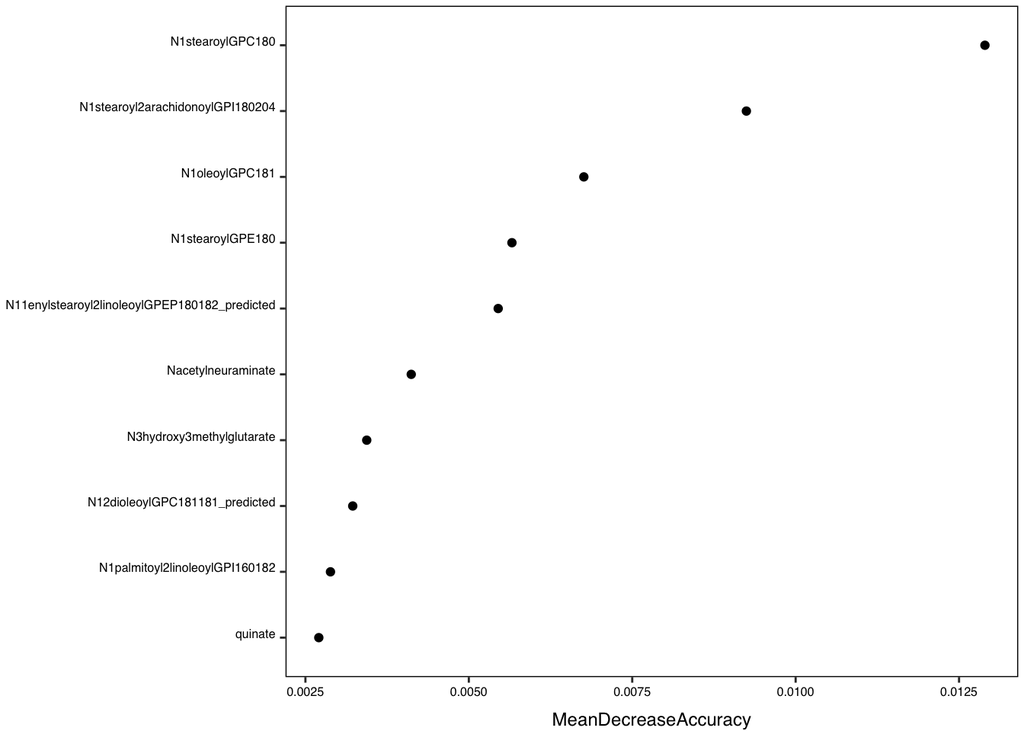

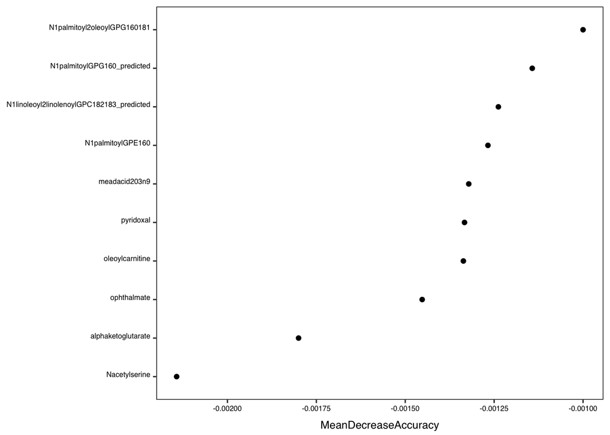

22 (DNA norm) RF blood classifier results

```
##
## Call:
##  randomForest(formula = formula, data = df, ntree = 500, importance = T,      classwt = c(0.33, 0.67), na.action = "na.omit")
##                Type of random forest: classification
##                      Number of trees: 500
## No. of variables tried at each split: 17
##
##         OOB estimate of  error rate: 30%
## Confusion matrix:
##    1 23 class.error
## 1  4  4   0.5000000
## 23 2 10   0.1666667
```

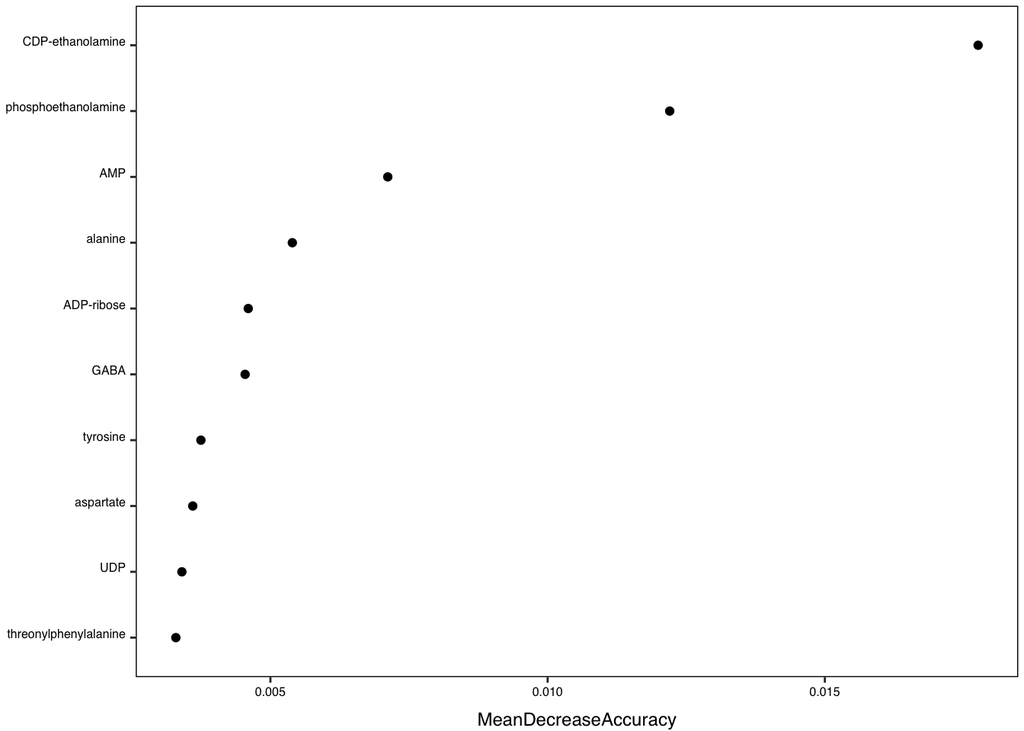

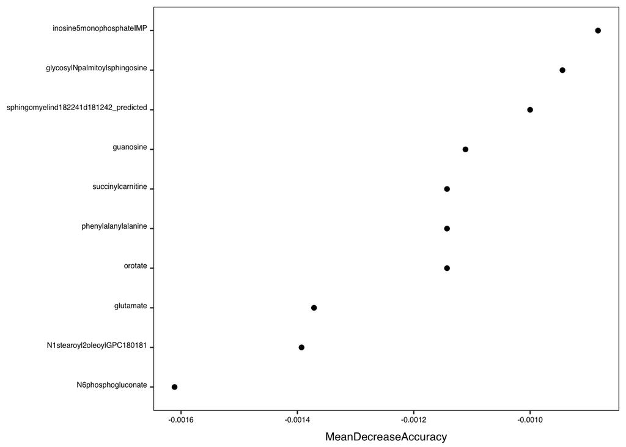

23 (Protein norm) RF blood classifier results

```
##
## Call:
##  randomForest(formula = formula, data = df, ntree = 500, importance = T,      classwt = c(0.33, 0.67), na.action = "na.omit")
##                Type of random forest: classification
##                      Number of trees: 500
## No. of variables tried at each split: 17
##
##         OOB estimate of  error rate: 50%
## Confusion matrix:
##    1 23 class.error
## 1  2  6   0.7500000
## 23 4  8   0.3333333
```

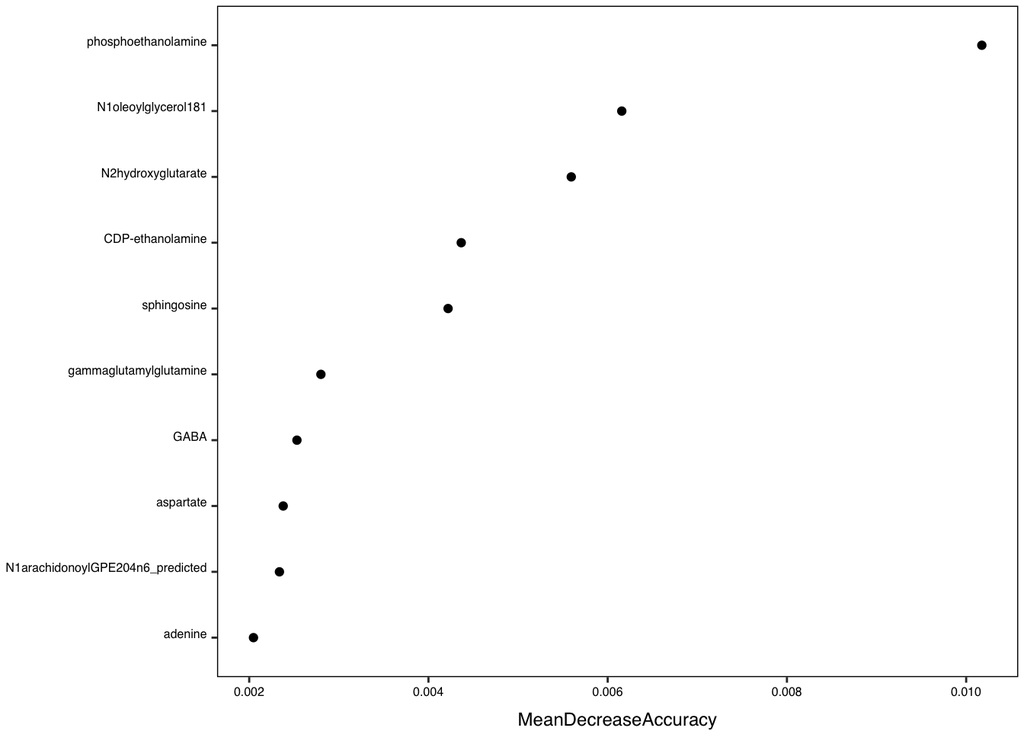

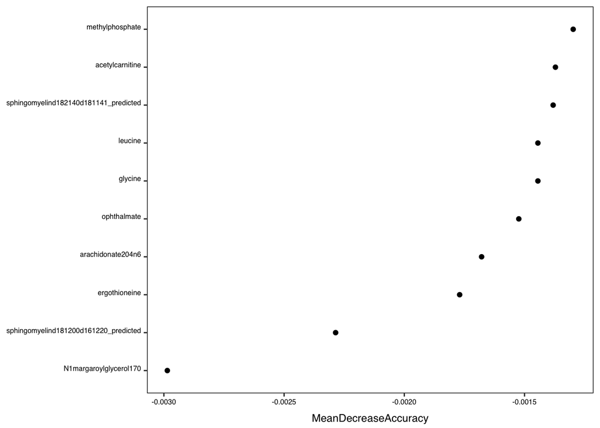

24 (Parasite number norm) RF blood classifier results

```
##
## Call:
##  randomForest(formula = formula, data = df, ntree = 500, importance = T,      classwt = c(0.33, 0.67), na.action = "na.omit")
##                Type of random forest: classification
##                      Number of trees: 500
## No. of variables tried at each split: 17
##
##         OOB estimate of  error rate: 40%
## Confusion matrix:
##    1 23 class.error
## 1  2  6   0.7500000
## 23 2 10   0.1666667
```

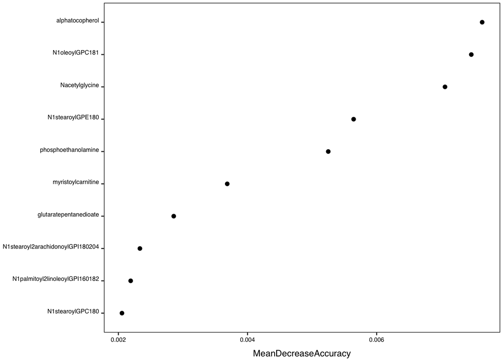

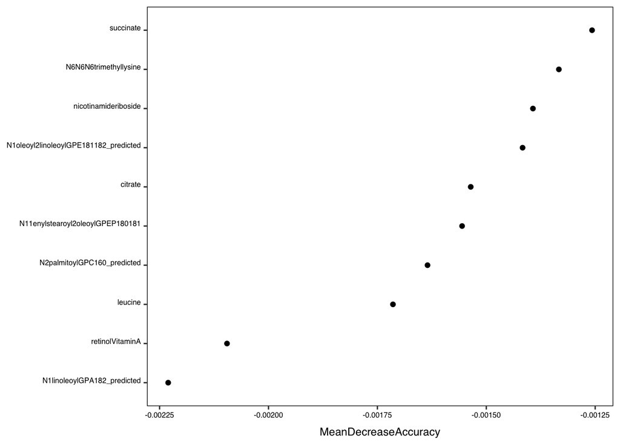

25 (DNA and HEPES norm) RF blood classifier results

```
##
## Call:
##  randomForest(formula = formula, data = df, ntree = 500, importance = T,      classwt = c(0.33, 0.67), na.action = "na.omit")
##                Type of random forest: classification
##                      Number of trees: 500
## No. of variables tried at each split: 14
##
##         OOB estimate of  error rate: 45%
## Confusion matrix:
##    1 23 class.error
## 1  2  6        0.75
## 23 3  9        0.25
```

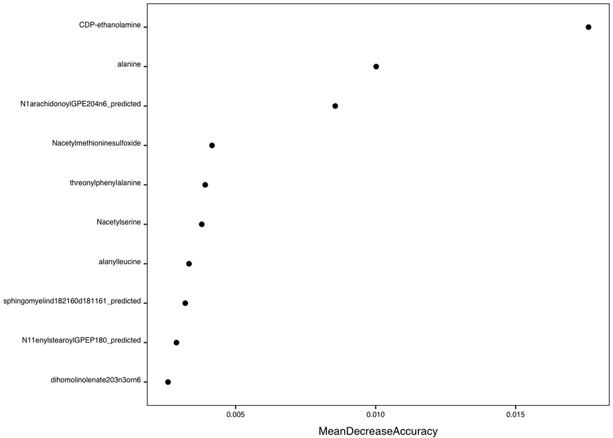

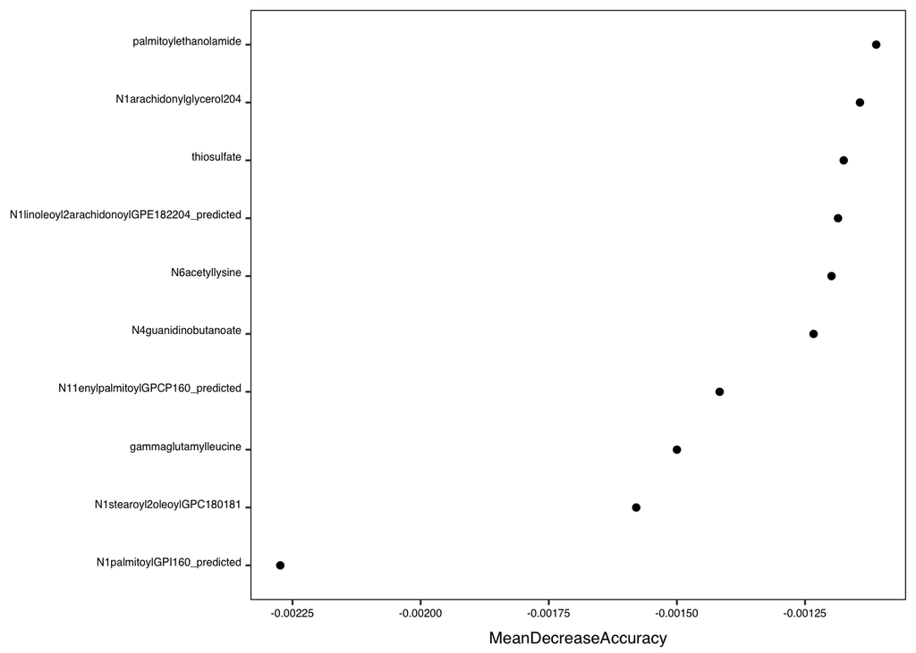

25 RF blood classifier results - into table

26 Predict sample group : RF

```r
rf_Drug = c()
top = c()
top_table = c()
worst = c()
worst_table = c()
for(x in 1:5) {
  if (x == 1) {
    title = 'Unnormalized'; title2 = 'unnorm_'
  } else if (x == 2) {
    title = 'Normalized to DNA'
    title2 = 'dna_norm_'
  } else if (x == 3) {
    title = 'Normalized to Protein'
    title2 = 'pro_norm_'
  } else if (x == 4 ) {
    title = 'Normalized to Parasite Number'
    title2 = 'para_norm_'
  } else {
    title = ' Normalized to DNA and HEPES'
    title2 = 'dna_HEPES_norm_'
  }
  df = as.data.frame(comparison_2_df[[x]])
  df = mutate(df, sample = rownames(df), drug = substr(sample, nchar(sample)-4, nchar(sample)))
  rownames(df) = df$sample
  df$drug = as.factor(df$drug)
  df$sample = NULL; df$blood = NULL
  df[,-c(ncol(df))] = make_numeric(df[,-c(ncol(df))])

  # split into training and validation data set # NOT NEEDED FOR RF, inherent in implementation
  varNames = names(df); varNames = varNames[!varNames %in%  c("drug")]
  varNames1 = paste(varNames, collapse = "+")
  formula = as.formula(paste("drug", varNames1, sep = " ~ "))
  set.seed(2017) # for first submission date
  rf_Drug[[x]] = randomForest(formula, data = df, ntree=500, na.action = "na.omit", importance=T)

  #varImpPlot(rf_Drug, sort = T,main="Variable Importance for RF",n.var=10)
  drug_imp = as.data.frame(rf_Drug[[x]]$importance)
  drug_imp = drug_imp[order(drug_imp$MeanDecreaseAccuracy),]
  drug_imp_rf = drug_imp[,-c(1:2)]
  top_table[[x]] = drug_imp_rf
  top_drug_imp_rf = drug_imp_rf[(nrow(drug_imp_rf)-9):nrow(drug_imp_rf),]
  worst_drug_imp_rf = drug_imp_rf[1:10,]

  print(dim(drug_imp[drug_imp$MeanDecreaseAccuracy>0,]))

  # fancier plotting
  #print(ggplot() + geom_histogram(data=drug_imp_rf, aes(x = MeanDecreaseAccuracy), bins = 50) + ggtitle(title))

  # plot top blood predictors
  top_drug_imp_rf = mutate(top_drug_imp_rf, met = rownames(top_drug_imp_rf))

  top_drug_imp_rf$met[which(top_drug_imp_rf$met == 'N1palmitoyl2linoleoylGPG160182')] = '1-palmitoyl 2-linoleoylGPG'
  top_drug_imp_rf$met[which(top_drug_imp_rf$met == 'N1margaroylglycerol170')] = '1-margaroyl glycerol'
  top_drug_imp_rf$met[which(top_drug_imp_rf$met == 'N11enylstearoyl2linoleoylGPEP180182_predicted')] = '1-(1-enyl-stearoyl)\n2-linoleoyl-GPE (predicted)'
  top_drug_imp_rf$met[which(top_drug_imp_rf$met == 'eicosenoate201')] = 'eicosenoate'
  top_drug_imp_rf$met[which(top_drug_imp_rf$met == 'leucylglutamine_predicted')] = 'leucylglutamine (predicted)'
  top_drug_imp_rf$met[which(top_drug_imp_rf$met == 'Nacetylmethionine')] = 'acetylmethionine'
  top_drug_imp_rf$met[which(top_drug_imp_rf$met == 'N1margaroylglycerol170')] = '1-margaroyl glycerol'

  ordr = order(top_drug_imp_rf$MeanDecreaseAccuracy)
  top_drug_imp_rf$met <- factor(top_drug_imp_rf$met, levels = top_drug_imp_rf$met[ordr])

  top[[x]] = ggplot() + theme( plot.margin = unit(c(1,2.5,1,1),"mm")) +
    geom_point(data=top_drug_imp_rf, aes(x = MeanDecreaseAccuracy, y = factor(met))) +
    custom_theme_pca + ylab(NULL) #+
    #ggtitle(paste(title,'metabolites most predictive of drug treatment'))

  ggsave(paste(title2,'top_Drug_mets_feb2018.pdf'), top[[x]], width = 94, height = 50, units = "mm")
  # devSVG(file = paste(title2,'top_drug_mets_dec2017.svg'), width = 4.2, height = 3, xmlHeader = T)
  # top[[x]]
  # dev.off()

  #plot worst blood predictors
  worst_drug_imp_rf = mutate(worst_drug_imp_rf, met = rownames(worst_drug_imp_rf))
  ordr = order(worst_drug_imp_rf$MeanDecreaseAccuracy)
  worst_drug_imp_rf$met <- factor(worst_drug_imp_rf$met, levels = worst_drug_imp_rf$met[ordr])
  worst_table = worst_drug_imp_rf$met
  worst[[x]] = ggplot() +
    geom_point(data=worst_drug_imp_rf, aes(x = MeanDecreaseAccuracy, y = factor(met))) +
    custom_theme_pca + ylab(NULL)
    #ggtitle(paste(title,'metabolites least predictive of drug treatment')) +

  ggsave(paste(title2,'worst_Drug_mets_feb2018.pdf'), worst[[x]], width = 80, height = 60, units = "mm")
  # devSVG(file = paste(title2,'worst_drug_mets_dec2017.svg'), width = 4.2, height = 3, xmlHeader = T)
  # worst[[x]]
  # dev.off()

  rm(ordr, worst_drug_imp_rf, top_drug_imp_rf,drug_imp,df)
}
```

```
## [1] 84  4
```

```
## [1] 118   4
```

```
## [1] 87  4
```

```
## [1] 83  4
```

```
## [1] 83  4
```

27 Unnormalized RF drug classifier results

```
##
## Call:
##  randomForest(formula = formula, data = df, ntree = 500, importance = T,      na.action = "na.omit")
##                Type of random forest: classification
##                      Number of trees: 500
## No. of variables tried at each split: 17
##
##         OOB estimate of  error rate: 20%
## Confusion matrix:
##       _plus minus class.error
## _plus     9     1         0.1
## minus     3     7         0.3
```

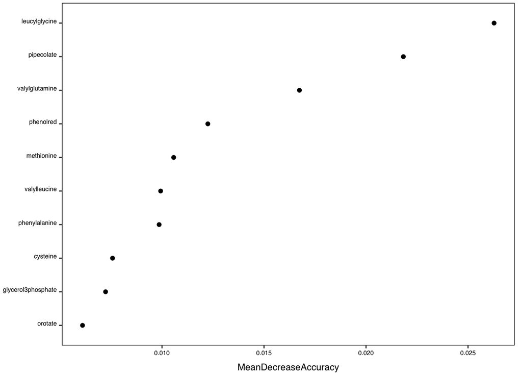

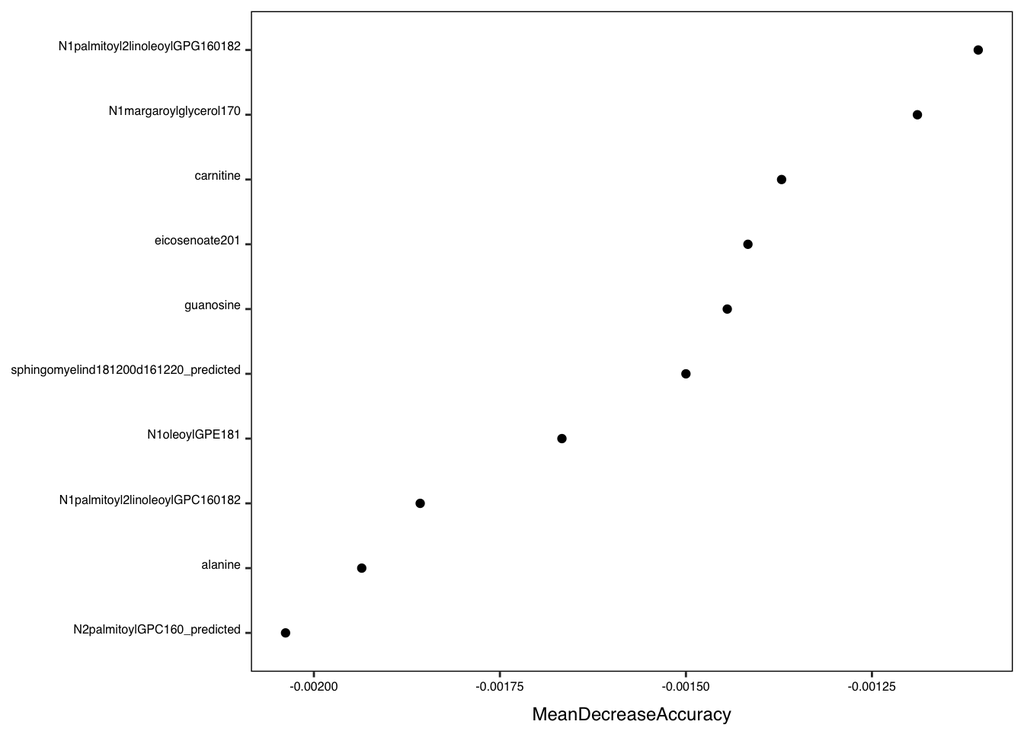

28 (DNA norm) RF drug classifier results

```
##
## Call:
##  randomForest(formula = formula, data = df, ntree = 500, importance = T,      na.action = "na.omit")
##                Type of random forest: classification
##                      Number of trees: 500
## No. of variables tried at each split: 17
##
##         OOB estimate of  error rate: 30%
## Confusion matrix:
##       _plus minus class.error
## _plus     7     3         0.3
## minus     3     7         0.3
```

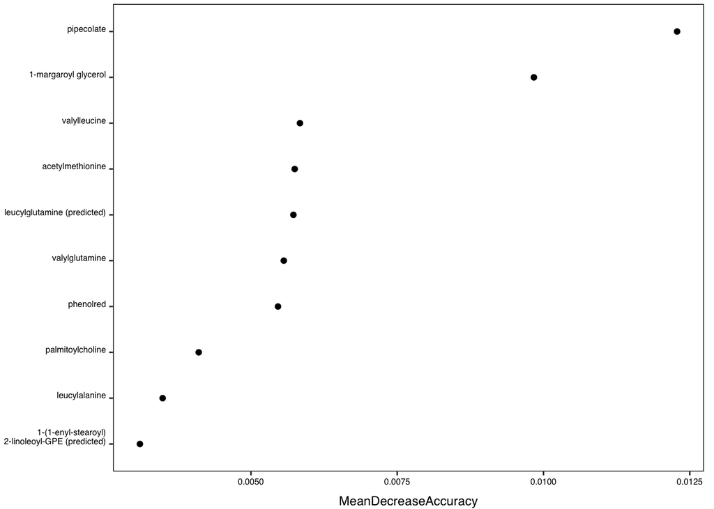

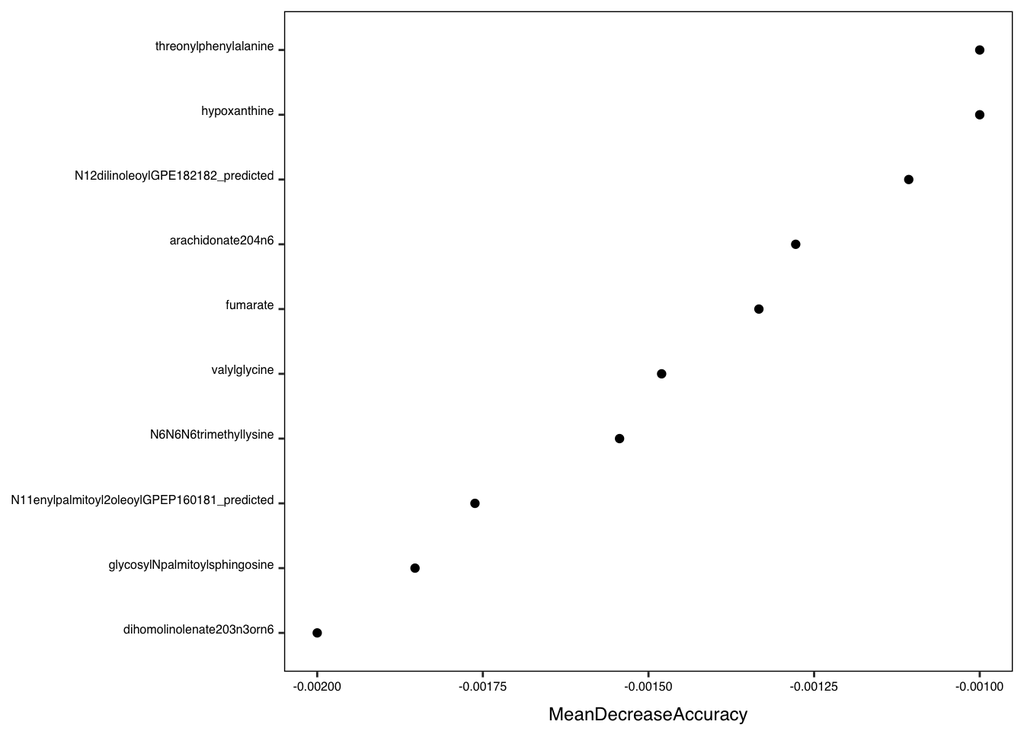

29 (Protein norm) RF drug classifier results

```
##
## Call:
##  randomForest(formula = formula, data = df, ntree = 500, importance = T,      na.action = "na.omit")
##                Type of random forest: classification
##                      Number of trees: 500
## No. of variables tried at each split: 17
##
##         OOB estimate of  error rate: 20%
## Confusion matrix:
##       _plus minus class.error
## _plus     8     2         0.2
## minus     2     8         0.2
```

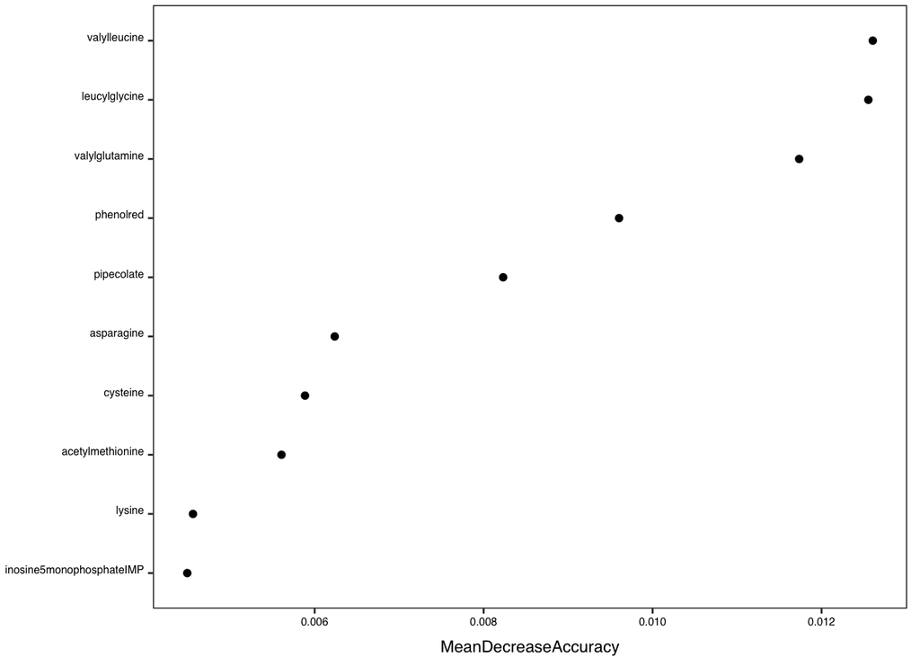

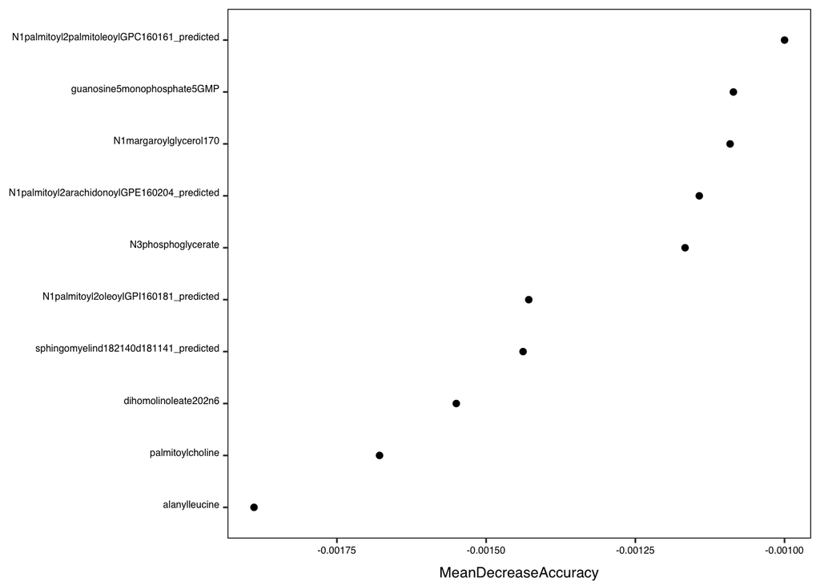

30 (Parasite number norm) RF drug classifier results

```
##
## Call:
##  randomForest(formula = formula, data = df, ntree = 500, importance = T,      na.action = "na.omit")
##                Type of random forest: classification
##                      Number of trees: 500
## No. of variables tried at each split: 17
##
##         OOB estimate of  error rate: 25%
## Confusion matrix:
##       _plus minus class.error
## _plus     9     1         0.1
## minus     4     6         0.4
```

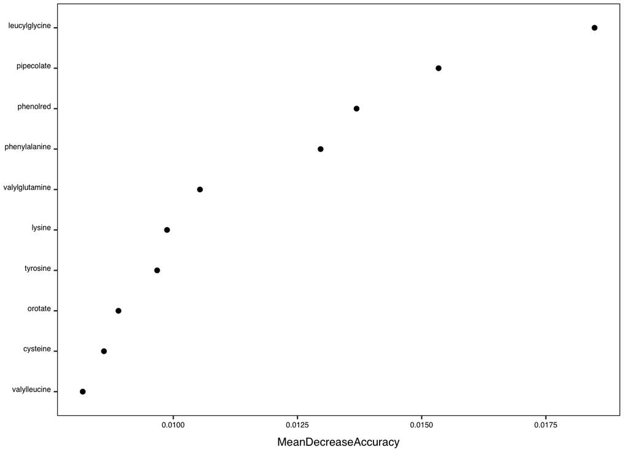

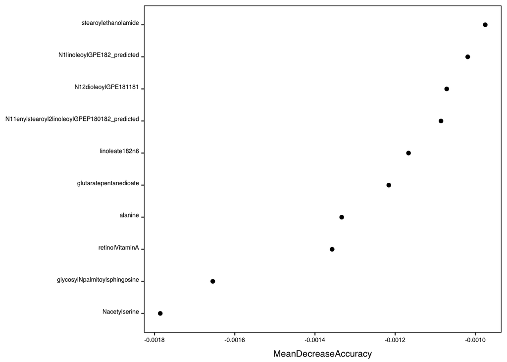

31 (DNA and HEPES norm) RF drug classifier results

```
##
## Call:
##  randomForest(formula = formula, data = df, ntree = 500, importance = T,      na.action = "na.omit")
##                Type of random forest: classification
##                      Number of trees: 500
## No. of variables tried at each split: 14
##
##         OOB estimate of  error rate: 25%
## Confusion matrix:
##       _plus minus class.error
## _plus     8     2         0.2
## minus     3     7         0.3
```

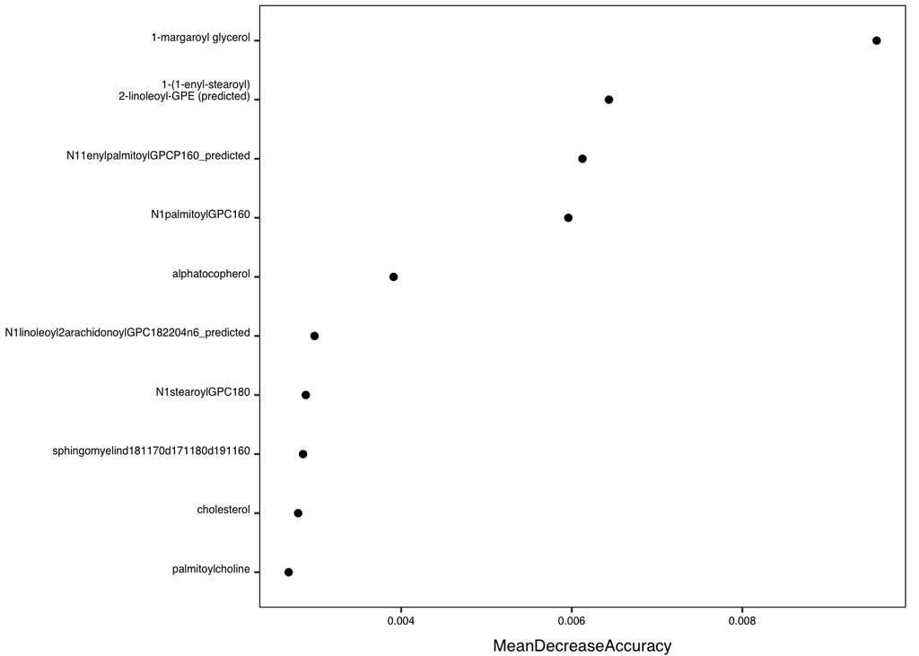

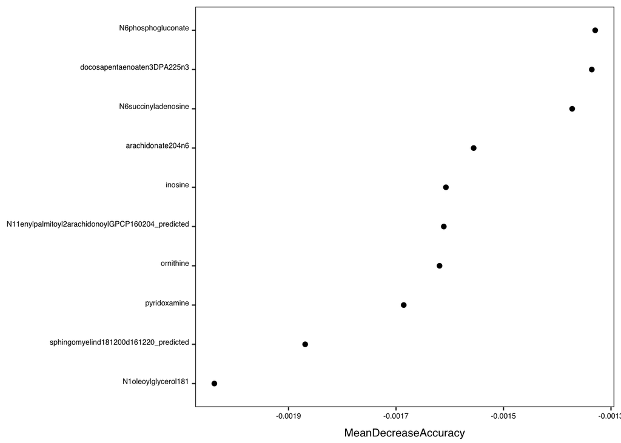

25 RF drug classifier results - into table

```
## [1] "contradictory mets for drug classifier"
```

```
##   [1] "N11enylpalmitoyl2arachidonoylGPCP160204_predicted"
##   [2] "alphaketoglutarate"
##   [3] "isocitrate"
##   [4] "Nmethylproline"
##   [5] "glycosylNpalmitoylsphingosine"
##   [6] "proline"
##   [7] "deoxycarnitine"
##   [8] "docosapentaenoaten3DPA225n3"
##   [9] "sphingomyelind182140d181141_predicted"
##  [10] "N12dilinoleoylGPE182182_predicted"
##  [11] "N12dioleoylGPC181181_predicted"
##  [12] "glutaratepentanedioate"
##  [13] "guanine"
##  [14] "inosine"
##  [15] "meadacid203n9"
```

[output cut: 174 more lines]

```
## [1] "contradictory mets in blood classifier"
```

```
##   [1] "adenine"
##   [2] "leucylglutamine_predicted"
##   [3] "N1palmitoyl2oleoylGPC160181"
##   [4] "linoleoylcarnitine_predicted"
##   [5] "glycerophosphoinositol_predicted"
##   [6] "N1stearoyl2linoleoylGPS180182"
##   [7] "N4guanidinobutanoate"
##   [8] "N11enylpalmitoyl2oleoylGPCP160181_predicted"
##   [9] "lactate"
##  [10] "N1palmitoyl2arachidonoylGPE160204_predicted"
##  [11] "N1margaroylglycerol170"
##  [12] "N1oleoyl2linoleoylGPC181182_predicted"
##  [13] "creatine"
##  [14] "nicotinate"
##  [15] "malate"
```

[output cut: 196 more lines]

```
## [1] "mets predictive of blood and drug"
```

```
##   [1] "linoleoylethanolamide"
##   [2] "leucylglutamine_predicted"
##   [3] "N1palmitoyl2oleoylGPC160181"
##   [4] "linoleoylcarnitine_predicted"
##   [5] "histidine"
##   [6] "glycerophosphoinositol_predicted"
##   [7] "N1stearoyl2linoleoylGPS180182"
##   [8] "N4guanidinobutanoate"
##   [9] "N1margaroylglycerol170"
##  [10] "creatine"
##  [11] "nicotinate"
##  [12] "N11enylstearoylGPEP180_predicted"
##  [13] "malate"
##  [14] "N1palmitoleoyl2linoleoylGPC161182_predicted"
##  [15] "N1stearoyl2linoleoylGPE180182_predicted"
```

[output cut: 187 more lines]

```
## [1] "mets antipredictive of blood and drug"
```

```
##   [1] "Nacetylserine"
##   [2] "alphaketoglutarate"
##   [3] "ophthalmate"
##   [4] "oleoylcarnitine"
##   [5] "pyridoxal"
##   [6] "meadacid203n9"
##   [7] "N1palmitoylGPE160"
##   [8] "N1linoleoyl2linolenoylGPC182183_predicted"
##   [9] "N1palmitoylGPG160_predicted"
##  [10] "N1palmitoyl2oleoylGPG160181"
##  [11] "dihomolinolenate203n3orn6"
##  [12] "nicotinamide"
##  [13] "arabonatexylonate"
##  [14] "tryptophan"
##  [15] "N11enylpalmitoyl2arachidonoylGPCP160204_predicted"
```

[output cut: 195 more lines]

```
##
##                                                             acetylcarnitine
##                                                                           1
##                                                    adenosine5diphosphateADP
##                                                                           2
##                                          adenosine5diphosphoriboseADPribose
##                                                                           1
##                                                  adenosine5monophosphateAMP
##                                                                           3
##                                                                     alanine
##                                                                           1
##                                                               alanylleucine
##                                                                           1
##                                                          alphaketoglutarate
##                                                                           2
##                                                             alphatocopherol
##                                                                           2
##                                                           arabonatexylonate
##                                                                           1
##                                                           arachidonate204n6
##                                                                           1
##                                                                    arginine
##                                                                           4
##                                                                  asparagine
##                                                                           4
##                                                                   aspartate
##                                                                           1
##                                      behenoylsphingomyelind181220_predicted
##                                                                           2
##                                                                   carnitine
##                                                                           1
##                                                                 cholesterol
##                                                                           2
##                                                                     choline
##                                                                           3
##                                                            cholinephosphate
##                                                                           1
##                                                                  citrulline
##                                                                           2
##                                                                   coenzymeA
```

[output cut: 414 more lines]

```
##                                                                           2
##                                                      uridine5diphosphateUDP
##                                                                           2
##                                                    uridine5monophosphateUMP
##                                                                           2
##                                                     uridine5triphosphateUTP
##                                                                           3
##                                                              valylglutamine
##                                                                           4
##                                                                valylglycine
##                                                                           3
##                                                                valylleucine
##                                                                           4
##                                                                    xanthine
##                                                                           1
```

```
##
##                                                             acetylcarnitine
##                                                                           1
##                                                         aconitatecisortrans
##                                                                           4
##                                                                     adenine
##                                                                           5
##                                                    adenosine5diphosphateADP
##                                                                           1
##                                          adenosine5diphosphoriboseADPribose
##                                                                           2
##                                                  adenosine5monophosphateAMP
##                                                                           1
##                                                                     alanine
##                                                                           4
##                                                               alanylleucine
##                                                                           2
##                                                          alphaketoglutarate
##                                                                           1
##                                                             alphatocopherol
##                                                                           3
##                                                           arabonatexylonate
##                                                                           1
##                                                           arachidonate204n6
##                                                                           3
##                                                                   aspartate
##                                                                           2
##                                      behenoylsphingomyelind181220_predicted
##                                                                           2
##                                                                   carnitine
##                                                                           3
##                                                                 cholesterol
##                                                                           2
##                                                                     choline
##                                                                           2
##                                                            cholinephosphate
##                                                                           3
##                                                                cisurocanate
##                                                                           4
##                                                                     citrate
```

[output cut: 440 more lines]

```
##                                                                           1
##                                                                   threonine
##                                                                           2
##                                                       threonylphenylalanine
##                                                                           2
##                                               trigonellineNmethylnicotinate
##                                                                           2
##                                                                  tryptophan
##                                                                           1
##                                                      uridine5diphosphateUDP
##                                                                           1
##                                                                valylglycine
##                                                                           1
##                                                                    xanthine
##                                                                           2
```

```
##
##                                           adenine
##                                                 3
##                adenosine5diphosphoriboseADPribose
##                                                 3
##                        adenosine5monophosphateAMP
##                                                 3
##                                           alanine
##                                                 2
##                                     alanylleucine
##                                                 4
##                                alphaketoglutarate
##                                                 1
##                                   alphatocopherol
##                                                 3
##                                 arabonatexylonate
##                                                 3
##                                 arachidonate204n6
##                                                 1
##                                          arginine
##                                                 1
##                                         aspartate
##                                                 2
##            behenoylsphingomyelind181220_predicted
##                                                 3
##                                         carnitine
##                                                 1
##                                       cholesterol
##                                                 1
##                                           choline
##                                                 1
##                                  cholinephosphate
##                                                 2
##                                      cisurocanate
##                                                 1
##                                           citrate
##                                                 1
##                                        citrulline
##                                                 1
##                                         coenzymeA
```

[output cut: 456 more lines]

```
##                                                 3
##                                        tryptophan
##                                                 1
##                                          tyrosine
##                                                 2
##                            uridine5diphosphateUDP
##                                                 2
##                          uridine5monophosphateUMP
##                                                 1
##                           uridine5triphosphateUTP
##                                                 2
##                                    valylglutamine
##                                                 1
##                                      valylglycine
##                                                 1
```

```
##
##                                                             acetylcarnitine
##                                                                           1
##                                                         aconitatecisortrans
##                                                                           2
##                                                                     adenine
##                                                                           2
##                                                                   adenosine
##                                                                           1
##                                                    adenosine5diphosphateADP
##                                                                           4
##                                                  adenosine5monophosphateAMP
##                                                                           1
##                                                                     alanine
##                                                                           3
##                                                          alphaketoglutarate
##                                                                           2
##                                                             alphatocopherol
##                                                                           1
##                                                           arabonatexylonate
##                                                                           2
##                                                           arachidonate204n6
##                                                                           3
##                                                                    arginine
##                                                                           1
##                                                                  asparagine
##                                                                           2
##                                                                   aspartate
##                                                                           1
##                                                                 cholesterol
##                                                                           2
##                                                                     choline
##                                                                           3
##                                                            cholinephosphate
##                                                                           3
##                                                                cisurocanate
##                                                                           3
##                                                                     citrate
##                                                                           3
##                                                                  citrulline
```

[output cut: 452 more lines]

```
##                                                                           2
##                                                      uridine5diphosphateUDP
##                                                                           2
##                                                    uridine5monophosphateUMP
##                                                                           1
##                                                     uridine5triphosphateUTP
##                                                                           1
##                                                              valylglutamine
##                                                                           2
##                                                                valylglycine
##                                                                           1
##                                                                valylleucine
##                                                                           3
##                                                                    xanthine
##                                                                           2
```

RBC DNA

```r
RBCdna = read.csv("/Users/maureencarey/local_documents/work/metabolomics_methods/data/urbc_dna_feb212018.csv",
                  sep = ",", header = T, stringsAsFactors = F)

RBCdna = mutate(RBCdna, imputed_value = ifelse(value == "Too Low", as.numeric(substr(LOD.1pg_per_ul.ul_for_resuspension.,1,nchar(LOD.1pg_per_ul.ul_for_resuspension.)-2)),value))

df = mutate(RBCdna, na = ifelse(value == "Too Low", 1, 0),
            new_value = ifelse(na == 1, as.numeric(0),as.numeric(as.character(value))))
```

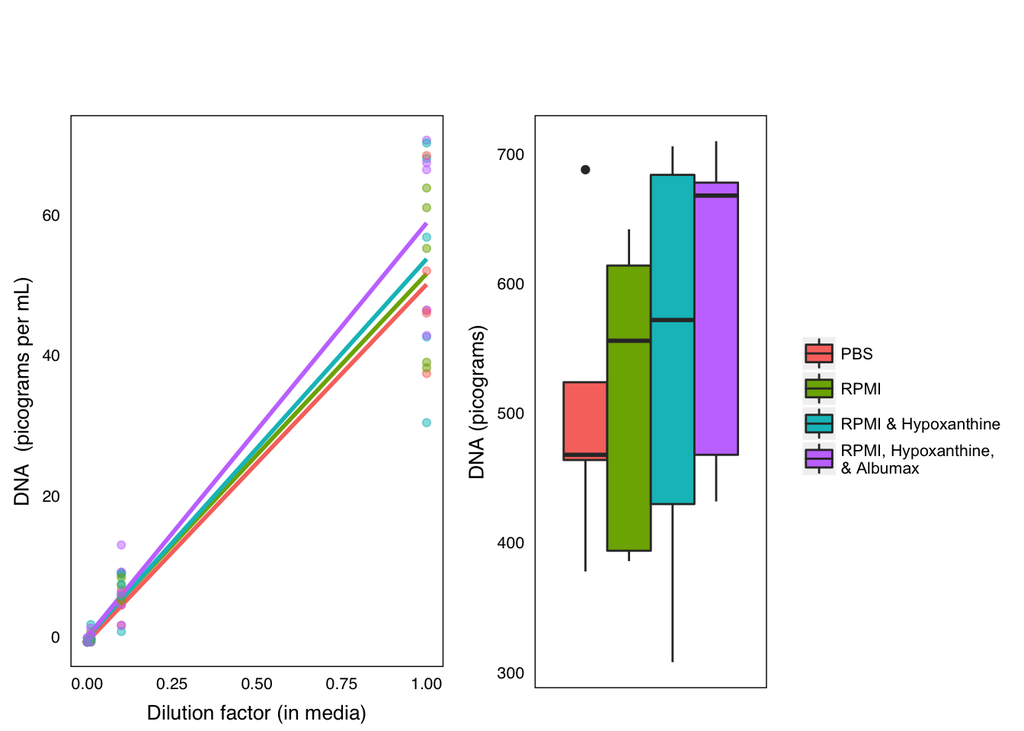

```r
p = ggplot(df, aes(x = dilution, y = new_value, color = media)) +
  #facet_wrap(~Blood.age) +
  geom_smooth(aes(group = media), method = "lm", se = F)  +
  geom_point(aes(group = media), alpha = 0.5)  +
  ylab('DNA  (picograms per mL)')+ guides(color = F) + theme(axis.ticks = element_blank(),
                                         plot.title = element_text(hjust = 0.5)) +
  xlab('Dilution factor (in media)') + custom_theme4 #+
  #ggtitle('Culture-derived DNA is primarily from erythrocytes')

df_undil = df[df$dilution == 1,]
df_undil = mutate(df_undil, media_legend = ifelse(media == 'RPMI_Hypoxanthine_Albumax',
                                                  'RPMI, Hypoxanthine,\n& Albumax',
                                                  gsub("_", " & ", media)))
p2 = ggplot(df_undil, aes(x = as.factor(dilution), y = new_value*10, fill = media_legend)) +
  geom_boxplot() + ylab('DNA (picograms)') +xlab('') + #ggtitle("DNA per culture flask") +
  custom_theme4 +
  theme(plot.title = element_text(hjust = 0.5),
        axis.ticks = element_blank(), axis.text.x = element_blank())

grid.newpage()
lay <- rbind(c(1,1,1,1,2,2,2,2,2),
             c(1,1,1,1,2,2,2,2,2))
plot_final = grid.arrange(p,p2,ncol = 2, nrow = 1, layout_matrix = lay)#, widths = 2:2)
```

```r
ggsave('March202018_S1.pdf',plot_final, height = 3, width = 6.875, units = "in")
```

Random forest with randomized data, per reviewer question

```r
set.seed(2017) # for first submission date

#random dataset
df = as.data.frame(matrix(replicate(20, rnorm(297)), nrow = 20, ncol = 297))
rownames(df) = colnames(raw_file)[30:49]
# label with 'groups'
df = mutate(df,
            sample = rownames(df),
            drug = substr(sample, nchar(sample)-4, nchar(sample)))
rownames(df) = df$sample
df$drug = as.factor(df$drug)
df$sample = NULL; df$blood = NULL
df[,-c(ncol(df))] = make_numeric(df[,-c(ncol(df))])

# split into training and validation data set # NOT NEEDED FOR RF, inherent in implementation
varNames = names(df); varNames = varNames[!varNames %in%  c("drug")]
varNames1 = paste(varNames, collapse = "+")
formula = as.formula(paste("drug", varNames1, sep = " ~ "))
rf_Drug = randomForest(formula, data = df, ntree=500, na.action = "na.omit", importance=T)

#varImpPlot(rf_Drug, sort = T,main="Variable Importance for RF",n.var=10)
drug_imp = as.data.frame(rf_Drug$importance)
drug_imp = drug_imp[order(drug_imp$MeanDecreaseAccuracy),]
drug_imp_rf = drug_imp[,-c(1:2)]
top_drug_imp_rf = drug_imp_rf[(nrow(drug_imp_rf)-9):nrow(drug_imp_rf),]
worst_drug_imp_rf = drug_imp_rf[1:10,]

print(dim(drug_imp[drug_imp$MeanDecreaseAccuracy>0,]))
```

```
## [1] 84  4
```

```r
# anything correlated in random dataset
df = as.data.frame(matrix(replicate(20, rnorm(297)), nrow = 20, ncol = 297))
rownames(df) = colnames(raw_file)[30:49]
cor_mat_temp = as.data.frame(matrix(, nrow = 0, ncol = ncol(df)))
for (y in 1:ncol(df)) {
  cor_data = cor.test(df[,1],df[,y], alternative = c("two.sided"), method = c("pearson"))
  cor_r = cor_data$estimate
  cor_p = cor_data$p.value
  colnames(cor_mat_temp)[y] = colnames(df)[y]
  cor_mat_temp[1,y] = cor_r
  cor_mat_temp[2,y] = cor_p }
cor_mat_temp[2,] = p.adjust(cor_mat_temp[2,], method = "fdr")
for (i in 1:ncol(cor_mat_temp)) {
  if (cor_mat_temp[2,i] > 0.05) {
    cor_mat_temp[2,i] = NA; cor_mat_temp[1,i] = NA } # if significant p value
  else if (abs(cor_mat_temp[1,i]) < 0.5) {
    cor_mat_temp[2,i] = NA; cor_mat_temp[1,i] = NA } } # if notable correlation coefficient
cor_mat = cor_mat_temp
cor_mat_count = cor_mat_temp[colSums(!is.na(cor_mat_temp)) > 0]
ifelse(dim(cor_mat_count)[[2]] >1,print(dim(cor_mat_count)[[2]]-1),print('no sig correlations'))
```

```
## [1] "no sig correlations"
```

```
## [1] "no sig correlations"
```